# Analysis of combined hatch rate data for Batch 8 and 9

## 5.2 Plotting the F2 male random effects (BLUPS) against the Bal and F1 means

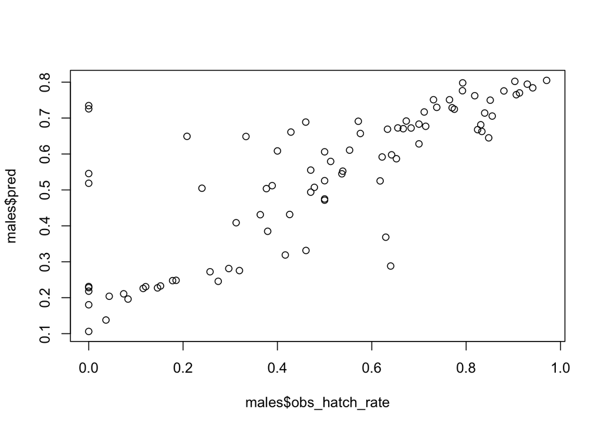

```r
ord  <- c("AmxBal", "AmxF1 Par6xBal", "AmxF1 BalxPar6",
          "AmxF2 Par6xBalxPar6xBal", "AmxF2 BalxPar6xBalxPar6", "AmxPar6")
ord2 <- c("Bal", "F1 (Par6×Bal)", "F1 (Bal×Par6)",
          "F2 (Par6×Bal)×(Par6×Bal)", "F2 (Bal×Par6)×(Bal×Par6)", "Par6")

# One row per male (couple)
males <- unique(dat_g[, c("CoupleID", "CrossType", "vargroup")])
males$pred <- predict(m_var, newdata = males, type = "conditional", re.form = NULL)

raw <- aggregate(cbind(LarvaeCount, EggCountCorr) ~ CoupleID, data = dat_g, FUN = sum)
males <- merge(males, raw, by = "CoupleID")
males$obs_hatch_rate <- males$LarvaeCount / males$EggCountCorr
plot(males$obs_hatch_rate, males$pred)          # quick check
```

```r
# Cross-type means with 95% CI (population level)
newdata <- data.frame(CrossType = ord, CoupleID = NA, EggCountCorr=100)
newdata$vargroup <- factor(as.integer(grepl("F2", ord)), levels = levels(dat_g$vargroup))  # same coding as the model
pr <- predict(m_var, newdata = newdata, type = "link", re.form = NA, se.fit = TRUE)
newdata$fit <- plogis(pr$fit)
newdata$lo  <- plogis(pr$fit - 1.96 * pr$se.fit)
newdata$hi  <- plogis(pr$fit + 1.96 * pr$se.fit)

# Same labels for both data frames
males$CrossType   <- factor(males$CrossType,   levels = ord, labels = ord2)
newdata$CrossType <- factor(newdata$CrossType, levels = ord, labels = ord2)

ref <- newdata[newdata$CrossType %in% c("Bal", "Par6"), ]
ref$lab  <- as.character(ref$CrossType)
ref$ylab <- ref$fit + ifelse(ref$lab == "Bal", 0.13, 0)    # raise Bal label only

males$Generation <- ifelse(grepl("F2", males$CrossType), "F2",
                    ifelse(grepl("F1", males$CrossType), "F1", "Parental"))

plt <- ggplot2::ggplot(males, aes(x = CrossType, y = pred)) +
  geom_hline(data = ref, aes(yintercept = fit), linetype = "dashed", colour = "grey40") +
  geom_jitter(aes(colour = Generation), width = 0.12, height = 0, size = 2.2, alpha = 0.75) +
  geom_pointrange(data = newdata, aes(y = fit, ymin = lo, ymax = hi),
                  position = position_nudge(x = 0.3), size = 0.4) +
  geom_label(data = ref, aes(x = 0.6, y = ylab, label = lab),
             hjust = 0, vjust = -0.3, size = 3.5, colour = "grey30",
             fill = "white", linewidth = 0, label.padding = unit(0.1, "lines")) +
  scale_y_continuous("Hatch rate excluding structural zeros", limits = c(0, 1)) +
  scale_colour_manual(values = c(Parental = "grey50", F1 = "#1b9e77", F2 = "#d95f02")) +
  labs(x = "Male genotype", colour = NULL) +
  theme_classic(base_size = 12) +
  theme(axis.text.x = element_text(angle = 30, hjust = 1), legend.position = "top")


#save bar plot
title_plot <- "BLUPS_Par6_Bal_F1_F2.png"
cowplot::save_plot(file = here::here("plots", title_plot),
                   plt, base_height = 12/cm(1),
                   base_width = 10/cm(1), dpi = 1200)
```

## 5.3 Compute Castle-Wright estimates

```r
vc   <- glmmTMB::VarCorr(m_var)$cond$CoupleID
# between-male variance, non-F2 groups
s2E  <- vc["vargroupOthers", "vargroupOthers"]
# between-male variance, F2
s2F2 <- vc["vargroupF2", "vargroupF2"]

## Mean hatch rate estimates  Bal - Par6 (Bal = reference)
b    <- glmmTMB::fixef(m_var)$cond
delta <- as.numeric((b["(Intercept)"]) - (b["(Intercept)"] + b["CrossTypeAmxPar6"]))

s2S <- s2F2 - s2E
n_e <- delta^2 / (8 * s2S)
c(s2E = s2E, s2F2 = s2F2, s2S = s2S, n_e = n_e)
```

```
      s2E      s2F2       s2S       n_e
0.2163207 1.1215404 0.9052197 0.6204424
```

## 5.4 Compute 95% confidence interval

```r
## Use prop to be able to use BootMer
m_var <- glmmTMB::glmmTMB(
  prop ~ CrossType + diag(0 + vargroup | CoupleID),
  ziformula = ~1, family = glmmTMB::betabinomial(), weights = EggCountCorr, data = dat_g)

## Statistics computed on each bootstrap refit
ne_fun <- function(.) {
  if (!isTRUE(.$sdr$pdHess)) return(rep(NA_real_, 6))      # drop unreliable refits
  vc    <- glmmTMB::VarCorr(.)$cond$CoupleID
  s2E   <- vc["vargroupOthers", "vargroupOthers"]            # between-male variance, non-F2
  s2F2  <- vc["vargroupF2", "vargroupF2"]                    # between-male variance, F2
  delta <- -unname(glmmTMB::fixef(.)$cond["CrossTypeAmxPar6"])  # Bal - Par6 (logit scale)
  s2S   <- s2F2 - s2E                                         # segregation variance

 return(c(s2E = s2E, s2F2 = s2F2, s2S = s2S, delta = delta,
    inv_ne = 8 * s2S / delta^2,                               # always finite
   n_e = if (s2S > 0) delta^2 / (8 * s2S) else Inf))
}

ne_fun(m_var)                                                # point estimates (check)
```

```
       s2E       s2F2        s2S      delta     inv_ne        n_e
 0.2163207  1.1215404  0.9052197 -2.1196918  1.6117532  0.6204424
```

```r
set.seed(123)
b_ne <- lme4::bootMer(m_var, FUN = ne_fun, nsim = 500, .progress = "txt")
## Keep successful refits
ok <- complete.cases(b_ne$t)
cat(sum(!ok), "of", nrow(b_ne$t), "refits dropped\n")
```

```
38 of 500 refits dropped
```

```r
## Extract the simulations that worked
t_ok <- b_ne$t[ok, ]
colnames(t_ok) <- names(b_ne$t0)

## Percentile intervals for the variance components and delta
apply(t_ok[, c("s2E", "s2F2", "s2S", "delta")], 2, quantile, c(0.025, 0.5, 0.975))
```

```
               s2E      s2F2         s2S     delta
2.5%  7.749091e-09 0.1646945 -0.01281206 -2.791064
50%   9.658423e-02 0.8935025  0.75160967 -2.148478
97.5% 4.076567e-01 1.8229952  1.72453764 -1.487430
```

```r
## Interval for n_e by inverting the interval for 1/n_e
q <- quantile(t_ok[, "inv_ne"], c(0.025, 0.10, 0.90, 0.975))
ne_ci <- c(lower95 = 1 / q[[4]], lower80 = 1 / q[[3]],
           upper80 = if (q[[2]] > 0) 1 / q[[2]] else Inf,
           upper95 = if (q[[1]] > 0) 1 / q[[1]] else Inf)
round(ne_ci, 2)
```

```
lower95 lower80 upper80 upper95
   0.23    0.35    2.73     Inf
```

```r
## Summaries for the text
mean(t_ok[, "n_e"] < 2)           # proportion of estimates below 2 loci
```

```
[1] 0.8614719
```

```r
mean(t_ok[, "s2S"] <= 0)          # proportion with no extra F2 variance
```

```
[1] 0.02597403
```

## 5.5 Simulations to check how environmental variation affect the position of F2 relative to the parents

```
## F2 males and their predicted hatch rates (logit scale)
f2 <- males[grepl("F2", males$CrossType), ]
lp <- qlogis(f2$pred)

## Class centres from the cross-type means (labels as relabelled for the plot)
ct_lab <- as.character(newdata$CrossType)
centres <- qlogis(c(
  Bal  = newdata$fit[ct_lab == "Bal"],
  F1   = mean(newdata$fit[grepl("F1", ct_lab)]),
  Par6 = newdata$fit[ct_lab == "Par6"]))
stopifnot(length(centres) == 3, !anyNA(centres))      # catch label mismatches

## Assign each F2 male to the nearest centre
classify <- function(v) factor(names(centres)[apply(abs(outer(v, centres, "-")), 1, which.min)],
                               levels = names(centres))
f2$class <- classify(lp)
obs <- table(f2$class)
obs

## Genetic parameters on the logit scale
mid <- mean(centres[c("Bal", "Par6")])
a   <- unname((centres["Bal"] - centres["Par6"]) / 2)
d   <- unname(centres["F1"] - mid)

## Environmental (between-male) SD from the model, non-F2 groups
vc   <- glmmTMB::VarCorr(m_var)$cond$CoupleID
sd_e <- sqrt(vc["vargroupOthers", "vargroupOthers"])

## Expected class proportions under n equal-effect loci
sim_props <- function(nloci, sd_e, n = 1e5) {
  x <- matrix(sample(c(-1, 0, 1), n * nloci, TRUE, c(0.25, 0.5, 0.25)), n)  # F2 genotypes
  g <- mid + a * rowMeans(x) + d * rowMeans(x == 0)                         # genotypic values
  as.numeric(prop.table(table(classify(g + rnorm(n, 0, sd_e)))))
}

set.seed(1)
props <- sapply(1:4, sim_props, sd_e = sd_e)
dimnames(props) <- list(names(centres), paste(1:4, "loci"))
round(props * sum(obs), 1)                  # expected counts under each hypothesis

## Goodness of fit of observed counts to each hypothesis
sapply(1:4, function(k) chisq.test(obs, p = props[, k],
                                   simulate.p.value = TRUE, B = 1e4)$p.value)
```

# 6 Make plot

```r
## Read data
data <- tibble::as_tibble(read.table(file = file.path(here::here(), "data", "derived_data", "confint_saturated_model_msat.csv"), sep=";", header = TRUE))

head(data)

##Filter only p2 hatch rate estimates
data <- data |>
  dplyr::filter(grepl("^cond\\.", Parameters))

## Filter cross types only for test cross to have observed line means
observed <- data |>
dplyr:: filter (CrossType %in% c ("AmxBal","AmxPar6","AmxF1 Par6xBal","AmxF1 BalxPar6", "AmxF2 Par6xBalxPar6xBal","AmxF2 BalxPar6xBalxPar6"))

##Change structure for the database
observed <- observed |>
  dplyr::filter(grepl("^cond\\.", Parameters)) |>
  dplyr::mutate(
    uninfstrain = sub("x.*$", "", CrossType),
    Strain   = sub("^[^x]*x", "", CrossType),
   Parameters)|>
  dplyr::rename(`2.5%` = X2.5.., `97.5%` = X97.5..) |>
  dplyr::select(uninfstrain, Strain, CrossType, n, Estimate, `2.5%`, `97.5%`)

##Add Cross and Strain to the observed line means
observed <- observed |>
dplyr:: mutate (Cross=c(rep("P1", 1), rep("F1", 1),  rep("F1", 1), rep("F2", 1), rep("F2", 1), rep("P2", 1)))

## Expected lines means
expected <- data.frame(Cross=c("P1", "P2", "F1", "F2"), prop_Bal =c(1, 0, 0.5, 0.5), expected_hatchrate = c(data$Estimate[data$Strain=="Bal"][2], data$Estimate[data$Strain=="Par6"][2], mean(c(data$Estimate[data$Strain=="Par6"][2], data$Estimate[data$Strain=="Bal"][2])), mean(c(data$Estimate[data$Strain=="Par6"][2], data$Estimate[data$Strain=="Bal"][2]))))

dat <- dplyr::left_join(observed, expected, by="Cross") |>
  dplyr::mutate(Strain=factor(Strain, levels=c("Bal","Par6","F1 Par6xBal","F1 BalxPar6", "F2 Par6xBalxPar6xBal","F2 BalxPar6xBalxPar6")))

dat <- dat |>
dplyr::distinct(Strain, .keep_all = TRUE)

#Prediction of the hatch rate depending on the proportion of Bal genes for the line in the figure
##Fit m2 model for additive effect only with parental strains (Additive autosomal effect)
###Load the data
 merged_data_p <- tibble::as_tibble(read.table(file = file.path(here::here(), "data", "derived_data", "CoupleID_test_cross.csv"), sep=";", header = TRUE))

strains <- c("Par6", "Bal")
crosstype <- paste0("Amx", strains)
dat_p <- merged_data_p[merged_data_p$CrossType%in%crosstype, ]

#Define variable for autosomal effect (Par6: 1, Bal:-1)
dat_p$alpha1 <- as.factor(dat_p$CrossType)
levels(dat_p$alpha1) <- c(-1, +1) # alphabetical order
dat_p$alpha1 <- as.numeric(as.character(dat_p$alpha1))

m2 <- glmmTMB::glmmTMB(prop ~ alpha1 , data=dat_p, ziformula = ~ 1 , family=glmmTMB::betabinomial(), weight=sum_eggcount_corr)
summary(m2)
glmmTMB::diagnose(m2)

newdata <- expand.grid(alpha1 = c(-1, 0, 1), dominance = -1, sum_eggcount_corr=100)
newdata$prop_Par6<- (newdata$alpha1 + 1)/2
newdata$prop_Bal <- 1-newdata$prop_Par6

## Add CrossType
newdata$CrossType <- "AmxBal"
newdata$pred.cond <- predict(m2, type="conditional", re.form=NA, newdata=newdata)

newdata$pred.cond2 <-predict(m2, type = "conditional",
        newdata = data.frame(alpha1 = c(-1, 0, 1), sum_eggcount_corr = 100))

#Download data for CoupleID
data_couple <- tibble::as_tibble(read.table(file = file.path(here::here(), "data", "derived_data", "CoupleID_test_cross.csv"), sep=";", header = TRUE)) #272 rows

#Add to CoupleID data proportion of Bal genes
dat_couple <- dplyr::left_join(data_couple, dat, by="CrossType") |>
  dplyr::mutate(Strain=factor(Strain, levels=c("Bal","Par6","F1 Par6xBal","F1 BalxPar6", "F2 Par6xBalxPar6xBal","F2 BalxPar6xBalxPar6")))

dat_couple$Strain_label <- dplyr::recode(
  dat_couple$Strain,
  "F2 Par6xBalxPar6xBal" = "F2 (Par6xBal)x(Par6xBal)",
  "F2 BalxPar6xBalxPar6" = "F2 (BalxPar6)x(BalxPar6)"
)

dat_couple$prop_Par6 <- 1-dat_couple$prop_Bal

#Change proportion of Par6 alleles for the figure
dat_couple <- dat_couple |>
  dplyr::mutate(
    prop_Par6 = dplyr::case_when(
      Strain == "F1 Par6xBal" ~ 0.46,
      Strain == "F1 BalxPar6" ~ 0.485,
      Strain == "F2 Par6xBalxPar6xBal" ~ 0.51,
      Strain == "F2 BalxPar6xBalxPar6" ~ 0.535,
      TRUE ~ prop_Par6 ) )

#Change strain names for F2 in dat database
dat$Strain_label <- dplyr::recode(
  dat$Strain,
  "F2 Par6xBalxPar6xBal" = "F2 (Par6xBal)x(Par6xBal)",
  "F2 BalxPar6xBalxPar6" = "F2 (BalxPar6)x(BalxPar6)"
)

dat$prop_Par6 <- 1-dat$prop_Bal

dat <- dat |>
  dplyr::mutate(
    prop_Par6 = dplyr::case_when(
      Strain_label == "F1 Par6xBal" ~ 0.46,
      Strain_label == "F1 BalxPar6" ~ 0.485,
      Strain_label == "F2 (Par6xBal)x(Par6xBal)" ~ 0.51,
      Strain_label == "F2 (BalxPar6)x(BalxPar6)" ~ 0.535,
      TRUE ~ prop_Par6))

#Make columns for coordinates of labels in the plot
dat <- dat |>
  dplyr::mutate(
    label_x = dplyr::case_when(
      Strain == "Par6" ~ prop_Par6 + 0.05,
      Strain == "Bal" ~ prop_Par6 - 0.05,
      Strain == "F1 Par6xBal" ~ prop_Par6 - 0.145,
      Strain == "F1 BalxPar6" ~ prop_Par6 + 0.165,
      Strain == "F2 Par6xBalxPar6xBal" ~ prop_Par6 - 0.260,
      Strain == "F2 BalxPar6xBalxPar6" ~ prop_Par6 + 0.240,
      TRUE ~ prop_Par6
    ),
    label_y = dplyr::case_when(
      Strain == "Par6" ~ Estimate + 0.06,
      Strain == "Bal" ~ Estimate - 0.05,
      Strain == "F1 Par6xBal" ~ Estimate + 0.03,
      Strain == "F1 BalxPar6" ~ Estimate + 0.05,
      Strain == "F2 Par6xBalxPar6xBal" ~ Estimate-0.04,
      Strain == "F2 BalxPar6xBalxPar6" ~ Estimate-0.04,
      TRUE ~ Estimate
    )
  )

## Figure 5 with hatch rate in F1 anf F2 of crosses Bal and Par6 lines
pBal <- ggplot() +
  geom_jitter(data = dat_couple, aes(x = prop_Par6, y = hatchrate, color = Strain_label), width = 0.005, height = 0, size = 9, alpha = 0.6) +
  geom_errorbar(data = dat, aes(x = prop_Par6, ymin = `2.5%`, ymax = `97.5%`), width = 0.04, linewidth = 3.9, color = "black") +
  geom_point(data = dat, aes(x = prop_Par6, y = Estimate, fill = Strain_label), size = 45, shape = 21, alpha = 0.6, color = "black", stroke = 4.5) +
  geom_text(data = dat, aes(x = label_x, y = label_y, label = Strain_label, color = Strain_label), size = 25, fontface = "bold", show.legend = FALSE) +
  geom_line(data = newdata, aes(x = prop_Par6, y = pred.cond), color = "black", linewidth = 1.5) +
  scale_color_manual(values = c("Par6" = "violet", "Bal" = "#F8766D", "F1 Par6xBal" = "#00B6EB", "F1 BalxPar6" = "#00C094", "F2 (Par6xBal)x(Par6xBal)" = "#53B400", "F2 (BalxPar6)x(BalxPar6)" = "#A58AFF")) +
  scale_fill_manual(values = c("Par6" = "violet", "Bal" = "#F8766D", "F1 Par6xBal" = "#00B6EB", "F1 BalxPar6" = "#00C094", "F2 (Par6xBal)x(Par6xBal)" = "#53B400", "F2 (BalxPar6)x(BalxPar6)" = "#A58AFF")) +
  labs(x = "Proportion of Par6 suppressor allele(s)", y = "Hatch rate in test cross", color = "Male strain") +
  theme(plot.title = element_text(size = 90, face = "bold", hjust = 0.5, margin = margin(b = 60)), plot.margin = margin(t = 120, r = 90, b = 120, l = 120), axis.text = element_text(size = 75), axis.title = element_text(size = 90, face = "bold"), axis.title.x = element_text(margin = margin(t = 60)), axis.title.y = element_text(margin = margin(r = 60)), legend.position = "none")


pBal
#save bar plot
title_plot <- "Hatch_rate_F1_F2_Par6_Balv3.pdf"
cowplot::save_plot(file = here::here("plots", title_plot),
                   pBal, base_height = 30/cm(1),
                   base_width = 40/cm(1), dpi = 1200)
```

```r
## Read data
data <- tibble::as_tibble(read.table(file = file.path(here::here(), "data", "derived_data", "confint_saturated_model_msat.csv"), sep=";", header = TRUE))

head(data)

#Make column with CrossType
data <- data |>
dplyr::mutate(CrossType = sub(".*CrossType", "", Type))

data <- data |>
dplyr::distinct(CrossType, .keep_all = TRUE)

## Filter cross types only for test cross to have observed line means
observed <- data |>
dplyr:: filter (CrossType %in% c ("AmxBal","AmxPar6","AmxF1 Par6xBal","AmxF1 BalxPar6", "AmxF2 Par6xBalxPar6xBal","AmxF2 BalxPar6xBalxPar6"))

##Add Cross and Strain to the observed line means
observed <- observed |>
dplyr:: mutate (Cross=c(rep("P1", 1), rep("P2", 1), rep("F1", 1), rep("F2", 1), rep("F1", 1), rep("F2", 1))) |>
dplyr:: mutate (Strain= infstrain)

## Expected lines means
expected <- data.frame(Cross=c("P1", "P2", "F1", "F2"), prop_Bal =c(1, 0, 0.5, 0.5), expected_hatchrate = c(data$Estimate[data$infstrain=="Bal"][2], data$Estimate[data$infstrain=="Par6"][2], mean(c(data$Estimate[data$infstrain=="Par6"][2], data$Estimate[data$infstrain=="Bal"][2])), mean(c(data$Estimate[data$infstrain=="Par6"][2], data$Estimate[data$infstrain=="Bal"][2]))))

dat <- dplyr::left_join(observed, expected, by="Cross") |>
  dplyr::mutate(Strain=factor(Strain, levels=c("Bal","Par6","F1 Par6xBal","F1 BalxPar6", "F2 Par6xBalxPar6xBal","F2 BalxPar6xBalxPar6")))

dat <- dat |>
dplyr::distinct(Strain, .keep_all = TRUE)

#Prediction of the hatch rate depending on the proportion of Bal genes for the line in the figure
##Fit m2 model for additive effect only with parental strains (Additive autosomal effect)
###Load the data
 merged_data_p <- tibble::as_tibble(read.table(file = file.path(here::here(), "data", "derived_data", "CoupleID_test_cross.csv"), sep=";", header = TRUE))

strains <- c("Par6", "Bal")
crosstype <- paste0("Amx", strains)
dat_p <- merged_data_p[merged_data_p$CrossType%in%crosstype, ]

#Define variable for autosomal effect (Par6: 1, Bal:-1)
dat_p$alpha1 <- as.factor(dat_p$CrossType)
levels(dat_p$alpha1) <- c(-1, +1) # alphabetical order
dat_p$alpha1 <- as.numeric(as.character(dat_p$alpha1))

m2 <- glmmTMB::glmmTMB(prop ~ alpha1 + (1 | CoupleID) , data=dat_p, ziformula=~ -1+ CrossType , family=binomial, weight=sum_eggcount_corr)
summary(m2)
glmmTMB::diagnose(m2)

newdata <- expand.grid(alpha1 = c(-1, 0, 1), dominance = -1, sum_eggcount_corr=100)
newdata$prop_Par6<- (newdata$alpha1 + 1)/2
newdata$prop_Bal <- 1-newdata$prop_Par6

## Add CrossType
newdata$CrossType <- "AmxBal"
newdata$pred.cond <- predict(m2, type="conditional", re.form=NA, newdata=newdata)

#Download data for CoupleID
data_couple <- tibble::as_tibble(read.table(file = file.path(here::here(), "data", "derived_data", "CoupleID_test_cross.csv"), sep=";", header = TRUE)) #272 rows

#Add to CoupleID data proportion of Bal genes
dat_couple <- dplyr::left_join(data_couple, dat, by="CrossType") |>
  dplyr::mutate(Strain=factor(Strain, levels=c("Bal","Par6","F1 Par6xBal","F1 BalxPar6", "F2 Par6xBalxPar6xBal","F2 BalxPar6xBalxPar6")))

dat_couple$Strain_label <- dplyr::recode(
  dat_couple$Strain,
  "F2 Par6xBalxPar6xBal" = "F2 (Par6xBal)x(Par6xBal)",
  "F2 BalxPar6xBalxPar6" = "F2 (BalxPar6)x(BalxPar6)"
)

#Change proportion of Par6 alleles for the figure
dat_couple <- dat_couple |>
  dplyr::mutate(
    prop_Bal = dplyr::case_when(
      Strain == "F1 Par6xBal" ~ 0.46,
      Strain == "F1 BalxPar6" ~ 0.485,
      Strain == "F2 Par6xBalxPar6xBal" ~ 0.51,
      Strain == "F2 BalxPar6xBalxPar6" ~ 0.535,
      TRUE ~ prop_Bal ) )

dat_couple$prop_Par6 <- 1-dat_couple$prop_Bal

#Change strain names for F2
dat$Strain_label <- dplyr::recode(
  dat$Strain,
  "F2 Par6xBalxPar6xBal" = "F2 (Par6xBal)x(Par6xBal)",
  "F2 BalxPar6xBalxPar6" = "F2 (BalxPar6)x(BalxPar6)"
)

dat <- dat |>
  dplyr::mutate(
    prop_Bal = dplyr::case_when(
      Strain_label == "F1 Par6xBal" ~ 0.46,
      Strain_label == "F1 BalxPar6" ~ 0.485,
      Strain_label == "F2 (Par6xBal)x(Par6xBal)" ~ 0.51,
      Strain_label == "F2 (BalxPar6)x(BalxPar6)" ~ 0.535,
      TRUE ~ prop_Bal))

dat$prop_Par6 <- 1-dat$prop_Bal

#Make columns for coordinates of labels in the plot
dat <- dat |>
  dplyr::mutate(
    label_x = dplyr::case_when(
      Strain == "Par6" ~ prop_Par6 + 0.05,
      Strain == "Bal" ~ prop_Par6 - 0.05,
      Strain == "F1 Par6xBal" ~ prop_Par6 + 0.135,
      Strain == "F1 BalxPar6" ~ prop_Par6 + 0.145,
      Strain == "F2 Par6xBalxPar6xBal" ~ prop_Par6 - 0.260,
      Strain == "F2 BalxPar6xBalxPar6" ~ prop_Par6 - 0.240,
      TRUE ~ prop_Par6
    ),
    label_y = dplyr::case_when(
      Strain == "Par6" ~ Estimate + 0.07,
      Strain == "Bal" ~ Estimate - 0.05,
      Strain == "F1 Par6xBal" ~ Estimate + 0.03,
      Strain == "F1 BalxPar6" ~ Estimate + 0.06,
      Strain == "F2 Par6xBalxPar6xBal" ~ Estimate + 0.02,
      Strain == "F2 BalxPar6xBalxPar6" ~ Estimate + 0.02,
      TRUE ~ Estimate
    )
  )

## Figure 5 with hatch rate in F1 anf F2 of crosses Bal and Par6 lines
pBal <- ggplot() +
  geom_jitter(data = dat_couple, aes(x = prop_Par6, y = hatchrate, color = Strain_label), width = 0.005, height = 0, size = 9, alpha = 0.6) +
  geom_errorbar(data = dat, aes(x = prop_Par6, ymin = X2.5., ymax = X97.5.), width = 0.04, linewidth = 3.9, color = "black") +
  geom_point(data = dat, aes(x = prop_Par6, y = Estimate, fill = Strain_label), size = 45, shape = 21, alpha = 0.6, color = "black", stroke = 4.5) +
  geom_text(data = dat, aes(x = label_x, y = label_y, label = Strain_label, color = Strain_label), size = 30, fontface = "bold", show.legend = FALSE) +
  geom_line(data = newdata, aes(x = prop_Par6, y = pred.cond), color = "black", linewidth = 1.5) +
  scale_color_manual(values = c("Par6" = "violet", "Bal" = "#F8766D", "F1 Par6xBal" = "#00B6EB", "F1 BalxPar6" = "#00C094", "F2 (Par6xBal)x(Par6xBal)" = "#53B400", "F2 (BalxPar6)x(BalxPar6)" = "#A58AFF")) +
  scale_fill_manual(values = c("Par6" = "violet", "Bal" = "#F8766D", "F1 Par6xBal" = "#00B6EB", "F1 BalxPar6" = "#00C094", "F2 (Par6xBal)x(Par6xBal)" = "#53B400", "F2 (BalxPar6)x(BalxPar6)" = "#A58AFF")) +
  labs(x = "Proportion of Par6 suppressor allele(s)", y = "Hatch rate in test cross", color = "Male strain") +
  theme(plot.title = element_text(size = 90, face = "bold", hjust = 0.5, margin = margin(b = 60)), plot.margin = margin(t = 120, r = 90, b = 120, l = 120), axis.text = element_text(size = 75), axis.title = element_text(size = 90, face = "bold"), axis.title.x = element_text(margin = margin(t = 60)), axis.title.y = element_text(margin = margin(r = 60)), legend.position = "none")


pBal
#save bar plot
title_plot <- "Hatch_rate_F1_F2_Par6_Balv3.pdf"
cowplot::save_plot(file = here::here("plots", title_plot),
                   pBal, base_height = 30/cm(1),
                   base_width = 40/cm(1), dpi = 1200)
```

# 7 Plot predicted hatch rate for different genetic models

## 7.1 Plot for predicted F1 and F2 with cytoplasmic effect Par6 / Bal

```r
#Add predicted values for cytoplasmic effect
dat$cytopl <- dat$Estimate

cytopl_Par6 <- dat |> dplyr::filter(Strain == "Par6") |> dplyr::pull(cytopl) |> dplyr::first()
cytopl_bal <- dat |> dplyr::filter(Strain == "Bal") |> dplyr::pull(cytopl) |> dplyr::first()

dat <- dat |> dplyr::mutate(
    cytopl = dplyr::case_when(
     stringr::str_detect(Strain, "^(F1|F2) Par6x") ~ cytopl_Par6,
    stringr::str_detect(Strain, "^(F1|F2) Balx") ~ cytopl_bal,
      TRUE ~ cytopl))

dat <- dat |>
dplyr::distinct(Strain, .keep_all = TRUE)

#Add proportion of Par6 genes
dat$prop_Par6 <- 1-dat$prop_Bal

#Change proportion of Par6 for the figure
dat <- dat |>
  dplyr::mutate(
    prop_Par6 = dplyr::case_when(
      Strain == "F1 Par6xBal" ~ 0.460,
      Strain == "F1 BalxPar6" ~ 0.460,
      Strain == "F2 Par6xBalxPar6xBal" ~ 0.535,
      Strain == "F2 BalxPar6xBalxPar6" ~ 0.535,
      TRUE ~ prop_Par6))

#Change strain names for F2
dat$Strain_label <- dplyr::recode(
  dat$Strain,
  "F2 Par6xBalxPar6xBal" = "F2 (Par6xBal)x(Par6xBal)",
  "F2 BalxPar6xBalxPar6" = "F2 (BalxPar6)x(BalxPar6)")

#Make columns for coordinates of labeles in the plot
dat <- dat |>
  dplyr::mutate(
    label_x = dplyr::case_when(
      Strain_label == "Par6" ~ prop_Par6 + 0.06,
      Strain_label == "Bal" ~ prop_Par6 + 0.02,
      Strain_label == "F1 Par6xBal" ~ prop_Par6 - 0.12,
      Strain_label == "F1 BalxPar6" ~ prop_Par6 - 0.12,
      Strain_label == "F2 (Par6xBal)x(Par6xBal)" ~ prop_Par6 + 0.20,
      Strain_label == "F2 (BalxPar6)x(BalxPar6)" ~ prop_Par6 + 0.20,
      TRUE ~ prop_Par6
    ),
    label_y = dplyr::case_when(
      Strain_label == "Par6" ~ cytopl + 0.1,
      Strain_label == "Bal" ~ cytopl + 0.1,
      Strain_label == "F1 BalxPar6" ~ cytopl - 0.07,
      Strain_label == "F1 Par6xBal" ~ cytopl - 0.07,
      Strain_label == "F2 (Par6xBal)x(Par6xBal)" ~ cytopl + 0.08,
      Strain_label == "F2 (BalxPar6)x(BalxPar6)" ~ cytopl + 0.08,
      TRUE ~ cytopl
    )
  )

## Predicted hatch rate for cytoplasmic effect

pBal1 <- ggplot() +
  geom_line(data = newdata, aes(x = prop_Par6, y = pred.cond), color = "black", alpha = 0.6, linewidth = 1.5) +
  geom_point(data = dat, aes(x = prop_Par6, y = cytopl, fill = Strain_label), size = 25, shape = 21, alpha = 0.6, color = "black", stroke = 1.5) +
  geom_text(data = dat, aes(x = label_x, y = label_y, label = Strain_label, color = Strain_label), size = 10, fontface = "bold", show.legend = FALSE) +
  scale_color_manual(values = c("Par6" = "violet", "Bal" = "#F8766D", "F1 Par6xBal" = "#00B6EB", "F1 BalxPar6" = "#00C094", "F2 (Par6xBal)x(Par6xBal)" = "#53B400", "F2 (BalxPar6)x(BalxPar6)" = "#A58AFF")) +
  scale_fill_manual(values = c("Par6" = "violet", "Bal" = "#F8766D", "F1 Par6xBal" = "#00B6EB", "F1 BalxPar6" = "#00C094", "F2 (Par6xBal)x(Par6xBal)" = "#53B400", "F2 (BalxPar6)x(BalxPar6)" = "#A58AFF")) +
  scale_x_continuous(breaks = c(0, 0.5, 1), labels = c("0",  "0.5", "1"), expand = c(0.02, 0)) +
  scale_y_continuous(breaks = c(0, 0.5, 1), labels = c("0", "0.5","1"), expand = c(0, 0.02)) +
  labs(x = "Proportion of Par6 suppressor allele(s)", y = "Hatch rate in test cross", title = "Cytoplasmic effect") +
  annotate("segment", x = -0.1, xend = 1.03, y = 0, yend = 0, arrow = arrow(length = unit(0.6, "cm")), linewidth = 1.2, color = "black") +
  annotate("segment", x = -0.1, xend = -0.1, y = 0, yend = 1.03, arrow = arrow(length = unit(0.6, "cm")), linewidth = 1.2, color = "black") +
  coord_cartesian(xlim = c(-0.1, 1.03), ylim = c(0, 1.03), clip = "off") +
  theme_classic() +
  theme(plot.title = element_text(size = 60, face = "bold", hjust = 0.5, margin = margin(b = 20)), plot.margin = margin(t = 40, r = 60, b = 40, l = 40), axis.text = element_text(size = 40, color = "black"), axis.title = element_text(size = 50, face = "bold", color = "black"), axis.title.x = element_text(margin = margin(t = 20)), axis.title.y = element_text(margin = margin(r = 20)), axis.line = element_blank(), axis.ticks = element_blank(), legend.position = "none")

pBal1
#save bar plot
title_plot <- "Hatch_rate_F1_F2_Par6_Bal_cytopl.pdf"
cowplot::save_plot(file = here::here("plots", title_plot),
                   pBal1, base_height = 30/cm(1),
                   base_width = 40/cm(1), dpi = 1200)

# Only for F1

dat2<- dat |>
  dplyr::filter(Cross%in%c("P1", "P2", "F1" ))

## Predicted embryo mortality for cytoplasmic effect

pBal1_F1 <- ggplot() +
  geom_line(data = newdata, aes(x = prop_Bal, y = pred.mortality), color = "black", alpha = 0.6, linewidth = 1.5) +
  geom_point(data = dat2, aes(x = prop_Bal, y = cytopl, fill = Strain), size = 25, shape = 21, alpha = 0.6, color = "black", stroke = 1.5) +
  geom_text(data = dat2, aes(x = label_x, y = label_y, label = Strain_label, color = Strain), size = 10, fontface = "bold", show.legend = FALSE) +
  scale_color_manual(values = c("Par6" = "#A58AFF", "Bal" = "#F8766D", "F1 Par6xBal" = "royalblue", "F1 BalxPar6" = "#00C094", "F2 Par6xBalxPar6xBal" = "#53B400", "F2 BalxPar6xBalxPar6" = "violet")) +
  scale_fill_manual(values = c("Par6" = "#A58AFF", "Bal" = "#F8766D", "F1 Par6xBal" = "royalblue", "F1 BalxPar6" = "#00C094", "F2 Par6xBalxPar6xBal" = "#53B400", "F2 BalxPar6xBalxPar6" = "violet")) +
  scale_x_continuous(breaks = c(0, 0.5, 1), labels = c("0",  "0.5", "1"), expand = c(0.02, 0)) +
  scale_y_continuous(breaks = c(0, 0.5, 1), labels = c("0", "0.5","1"), expand = c(0, 0.02)) +
  labs(x = "Proportion of Bal genes", y = "Embryo mortality in test cross", title = "Cytoplasmic effect") +
  annotate("segment", x = -0.1, xend = 1.03, y = 0, yend = 0, arrow = arrow(length = unit(0.6, "cm")), linewidth = 1.2, color = "black") +
  annotate("segment", x = -0.1, xend = -0.1, y = 0, yend = 1.03, arrow = arrow(length = unit(0.6, "cm")), linewidth = 1.2, color = "black") +
  coord_cartesian(xlim = c(-0.1, 1.03), ylim = c(0, 1.03), clip = "off") +
  theme_classic() +
  theme(plot.title = element_text(size = 60, face = "bold", hjust = 0.5, margin = margin(b = 20)), plot.margin = margin(t = 40, r = 60, b = 40, l = 40), axis.text = element_text(size = 40, color = "black"), axis.title = element_text(size = 50, face = "bold", color = "black"), axis.title.x = element_text(margin = margin(t = 20)), axis.title.y = element_text(margin = margin(r = 20)), axis.line = element_blank(), axis.ticks = element_blank(), legend.position = "none")

pBal1_F1
#save bar plot
title_plot <- "Mortality_rate_F1_F2_Par6_Bal_cytopl_F1.pdf"
cowplot::save_plot(file = here::here("plots", title_plot),
                   pBal1_F1, base_height = 30/cm(1),
                   base_width = 40/cm(1), dpi = 1200)
```

```r
## Read data
data <- tibble::as_tibble(read.table(file = file.path(here::here(), "data", "derived_data", "confint_saturated_model_msat.csv"), sep=";", header = TRUE))

head(data)

#Make column with CrossType
data <- data |>
dplyr::mutate(CrossType = sub(".*CrossType", "", Type))


data <- data |>
dplyr::distinct(CrossType, .keep_all = TRUE)

## Filter cross types only for test cross to have observed line means
observed <- data |>
dplyr:: filter (CrossType %in% c ("AmxBal","AmxPar6","AmxF1 Par6xBal","AmxF1 BalxPar6", "AmxF2 Par6xBalxPar6xBal","AmxF2 BalxPar6xBalxPar6"))

observed <- observed |>
dplyr::mutate(Strain = sub("^Amx", "", CrossType))

observed <- observed |>
dplyr::mutate(Strain=factor(Strain, levels=c("Bal","Par6","F1 Par6xBal","F1 BalxPar6", "F2 Par6xBalxPar6xBal","F2 BalxPar6xBalxPar6")))

## Compute mortality using hatch rate data
observed <- observed |>
dplyr:: mutate (Mortality = (1-Estimate))

##Add Cross and Strain to the observed line means
observed <- observed |>
dplyr:: mutate (Cross=c(rep("P1", 1), rep("F1", 1), rep("F1", 1), rep("F2", 1),  rep("F2", 1), rep("P2", 1))) |>
  dplyr:: mutate (prop_Bal =c(1, 0.5, 0.5, 0.5, 0.5, 0))

observed <- observed |>
  dplyr::mutate(infstrain= Strain)

#Compute confidence intervals for mortality
dat <-observed |>
dplyr::mutate (X2.5m=1-X2.5..) |>
dplyr::mutate (X97.5m=1-X97.5..)

#Prediction of mortality depending on the proportion of Bal genes for the line in the figure
##Fit m2 model for additive effect only with parental strains (Additive autosomal effect)
###Load the data
 merged_data_p <- tibble::as_tibble(read.table(file = file.path(here::here(), "data", "derived_data", "CoupleID_test_cross.csv"), sep=";", header = TRUE))

strains <- c("Par6", "Bal")
crosstype <- paste0("Amx", strains)
dat_p <- merged_data_p[merged_data_p$CrossType%in%crosstype, ]

#Define variable for autosomal effect (Par6: 1, Bal:-1)
dat_p$alpha1 <- as.factor(dat_p$CrossType)
levels(dat_p$alpha1) <- c(-1, +1) # alphabetical order
dat_p$alpha1 <- as.numeric(as.character(dat_p$alpha1))

m2 <- glmmTMB::glmmTMB(prop ~ alpha1 + (1 | CoupleID) , data=dat_p, ziformula=~ -1+ CrossType , family=binomial, weight=sum_eggcount_corr)
summary(m2)
glmmTMB::diagnose(m2)

newdata <- expand.grid(alpha1 = c(-1, 0, 1), dominance = -1, sum_eggcount_corr=100)
newdata$prop_Bal <- (newdata$alpha1 + 1)/2

## Add CrossType
newdata$CrossType <- "AmxBal"
newdata$pred.cond <- predict(m2, type="conditional", re.form=NA, newdata=newdata)

#Mortality for the line in the figure

newdata$pred.mortality <- 1- newdata$pred.cond

#Dots with raw data in the figure
##Download data for CoupleID
data_couple <- tibble::as_tibble(read.table(file = file.path(here::here(), "data", "derived_data", "CoupleID_test_cross.csv"), sep=";", header = TRUE)) #272 rows

#Count mortality
data_couple <- data_couple |>
  dplyr::mutate (mortality = 1-hatchrate)

#Add to CoupleID data proportion of Bal genes
dat_couple <- dplyr::left_join(data_couple, dat, by="CrossType") |>
  dplyr::mutate(Strain=factor(Strain, levels=c("Bal","Par6","F1 Par6xBal","F1 BalxPar6", "F2 Par6xBalxPar6xBal","F2 BalxPar6xBalxPar6")))

#Change proportion of Bal genes for the figure
dat_couple <- dat_couple |>
  dplyr::mutate(
    prop_Bal = dplyr::case_when(
      Strain == "F1 Par6xBal" ~ 0.46,
      Strain == "F1 BalxPar6" ~ 0.485,
      Strain == "F2 Par6xBalxPar6xBal" ~ 0.51,
      Strain == "F2 BalxPar6xBalxPar6" ~ 0.535,
      TRUE ~ prop_Bal
    )
  )

dat <- dat |>
  dplyr::mutate(
    prop_Bal = dplyr::case_when(
      Strain == "F1 Par6xBal" ~ 0.46,
      Strain == "F1 BalxPar6" ~ 0.485,
      Strain == "F2 Par6xBalxPar6xBal" ~ 0.51,
      Strain == "F2 BalxPar6xBalxPar6" ~ 0.535,
      TRUE ~ prop_Bal
    )
  )

#Change strain names for F2
dat$Strain_label <- dplyr::recode(
  dat$Strain,
  "F2 Par6xBalxPar6xBal" = "F2 (Par6xBal)x(Par6xBal)",
  "F2 BalxPar6xBalxPar6" = "F2 (BalxPar6)x(BalxPar6)"
)

#Make columns for coordinates of labeles in the plot
dat <- dat |>
  dplyr::mutate(
    label_x = dplyr::case_when(
      Strain_label == "Par6" ~ prop_Bal + 0.05,
      Strain_label == "Bal" ~ prop_Bal - 0.05,
      Strain_label == "F1 Par6xBal" ~ prop_Bal - 0.135,
      Strain_label == "F1 BalxPar6" ~ prop_Bal - 0.135,
      Strain_label == "F2 (Par6xBal)x(Par6xBal)" ~ prop_Bal + 0.23,
      Strain_label == "F2 (BalxPar6)x(BalxPar6)" ~ prop_Bal + 0.23,
      TRUE ~ prop_Bal
    ),
    label_y = dplyr::case_when(
      Strain_label == "Par6" ~ Mortality + 0.075,
      Strain_label == "Bal" ~ Mortality + 0.05,
      Strain_label == "F1 BalxPar6" ~ Mortality - 0.05,
      TRUE ~ Mortality
    )
  )

## Figure 6 with hatch rate in F1 anf F2 of crosses Bal and Par6 lines
pBal <- ggplot() +
  geom_jitter(data = dat_couple, aes(x = prop_Bal, y = mortality, color = Strain), width = 0.005, height = 0, size = 3, alpha = 0.6 ) + #row data for CoupleID color = "grey40"
  geom_errorbar(data = dat, aes(x = prop_Bal, ymin = X2.5m, ymax = X97.5m), width = 0.04, size = 1.3, alpha = 0.4, color = "black") + #confidence intervals
  geom_point(data = dat, aes(x = prop_Bal, y = Mortality, fill = Strain), size = 15, shape = 21, alpha = 0.6, color = "black", stroke = 1.5) + #Mean hatch rate estimation from the model
  geom_text(data = dat, aes(x = label_x, y = label_y, label = Strain_label, color = Strain), size = 10, fontface = "bold", show.legend = FALSE) + #labels of strains
  geom_line(data = newdata, aes(x = prop_Bal, y = pred.mortality), color = "black" ) + #line with predicted estimation from additive model , linewidth = 0.5
  scale_color_manual(values = c("Par6" = "#A58AFF", "Bal" = "#F8766D", "F1 Par6xBal" = "royalblue", "F1 BalxPar6" = "#00C094", "F2 Par6xBalxPar6xBal" = "#53B400", "F2 BalxPar6xBalxPar6" = "violet")) + #colors for each strain
  scale_fill_manual(values = c("Par6" = "#A58AFF", "Bal" = "#F8766D", "F1 Par6xBal" = "royalblue", "F1 BalxPar6" = "#00C094", "F2 Par6xBalxPar6xBal" = "#53B400", "F2 BalxPar6xBalxPar6" = "violet")) + #colors for each strain
  labs(x = "Proportion of Bal genes", y = "Embryo mortality rate in test cross", color = "Male strain") +
  theme(plot.title = element_text(size = 30, face = "bold", hjust = 0.5, margin = margin(b = 20)), plot.margin = margin(t = 40, r = 30, b = 40, l = 40), axis.text = element_text(size = 25), axis.title = element_text(size = 30, face = "bold"), axis.title.x = element_text(margin = margin(t = 20)), axis.title.y = element_text(margin = margin(r = 20)), legend.position = "none")


pBal
#save bar plot
title_plot <- "Mortality_F1_F2_Par6_Bal2.pdf"
cowplot::save_plot(file = here::here("plots", title_plot),
                   pBal, base_height = 30/cm(1),
                   base_width = 40/cm(1), dpi = 1200)
```

## 7.2 Plot for predicted F1 and F2 with dominant effect Par6 / Bal

```r
#Add proportion of Par6 genes
dat$prop_Par6 <- 1-dat$prop_Bal

#Add predicted values for dominance effect
dat$dominance <- dat$Estimate

par6 <- dat |>
  dplyr::filter(Strain == "Par6") |>
  dplyr::pull(dominance) |>
  dplyr::first()

bal <- dat |>
  dplyr::filter(Strain == "Bal") |>
  dplyr::pull(dominance) |>
  dplyr::first()


dom_F1 <- par6
dom_F2 <- par6 + (bal - par6) * 0.25

dat <- dat |> dplyr::mutate(
    dominance = dplyr::case_when(
     stringr::str_detect(Strain, "F1 ") ~ dom_F1,
    stringr::str_detect(Strain, "F2 ") ~ dom_F2,
      TRUE ~ dominance))

#Change proportion of Par6 for the figure
dat <- dat |>
  dplyr::mutate(
    prop_Par6 = dplyr::case_when(
      Strain == "F1 Par6xBal" ~ 0.460,
      Strain == "F1 BalxPar6" ~ 0.535,
      Strain == "F2 Par6xBalxPar6xBal" ~ 0.460,
      Strain == "F2 BalxPar6xBalxPar6" ~ 0.535,
      TRUE ~ prop_Par6
    )
  )

#Make columns for coordinates of labeles in the plot
dat <- dat |>
  dplyr::mutate(
    label_x = dplyr::case_when(
      Strain_label == "Par6" ~ prop_Par6 + 0.06,
      Strain_label == "Bal" ~ prop_Par6 + 0.02,
      Strain_label == "F1 Par6xBal" ~ prop_Par6 - 0.12,
      Strain_label == "F1 BalxPar6" ~ prop_Par6 + 0.14,
      Strain_label == "F2 (Par6xBal)x(Par6xBal)" ~ prop_Par6 - 0.20,
      Strain_label == "F2 (BalxPar6)x(BalxPar6)" ~ prop_Par6 + 0.22,
      TRUE ~ prop_Par6
    ),
    label_y = dplyr::case_when(
      Strain_label == "Par6" ~ dominance + 0.1,
      Strain_label == "Bal" ~ dominance + 0.1,
      Strain_label == "F1 BalxPar6" ~ dominance + 0.08,
      Strain_label == "F1 Par6xBal" ~ dominance + 0.08,
      Strain_label == "F2 (Par6xBal)x(Par6xBal)" ~ dominance - 0.1,
      Strain_label == "F2 (BalxPar6)x(BalxPar6)" ~ dominance - 0.15,
      TRUE ~ dominance
    )
  )

## Predicted hatch rate for dominant effect

pBal2 <- ggplot() +
  geom_line(data = newdata, aes(x = prop_Par6, y = pred.cond), color = "black", alpha = 0.6, linewidth = 1.5) +
  geom_point(data = dat, aes(x = prop_Par6, y = dominance, fill = Strain_label), size = 25, shape = 21, alpha = 0.6, color = "black", stroke = 1.5) +
  geom_text(data = dat, aes(x = label_x, y = label_y, label = Strain_label, color = Strain_label), size = 10, fontface = "bold", show.legend = FALSE) +
  scale_color_manual(values = c("Par6" = "violet", "Bal" = "#F8766D", "F1 Par6xBal" = "#00B6EB", "F1 BalxPar6" = "#00C094", "F2 (Par6xBal)x(Par6xBal)" = "#53B400", "F2 (BalxPar6)x(BalxPar6)" = "#A58AFF")) +
  scale_fill_manual(values = c("Par6" = "violet", "Bal" = "#F8766D", "F1 Par6xBal" = "#00B6EB", "F1 BalxPar6" = "#00C094", "F2 (Par6xBal)x(Par6xBal)" = "#53B400", "F2 (BalxPar6)x(BalxPar6)" = "#A58AFF")) +
  scale_x_continuous(breaks = c(0, 0.5, 1), labels = c("0",  "0.5", "1"), expand = c(0.02, 0)) +
  scale_y_continuous(breaks = c(0, 0.5, 1), labels = c("0", "0.5","1"), expand = c(0, 0.02)) +
  labs(x = "Proportion of Par6 suppressor allele(s)", y = "Hatch rate in test cross", title = "Dominant effect") +
  annotate("segment", x = -0.1, xend = 1.03, y = 0, yend = 0, arrow = arrow(length = unit(0.6, "cm")), linewidth = 1.2, color = "black") +
  annotate("segment", x = -0.1, xend = -0.1, y = 0, yend = 1.03, arrow = arrow(length = unit(0.6, "cm")), linewidth = 1.2, color = "black") +
  coord_cartesian(xlim = c(-0.1, 1.03), ylim = c(0, 1.03), clip = "off") +
  theme_classic() +
  theme(plot.title = element_text(size = 60, face = "bold", hjust = 0.5, margin = margin(b = 20)), plot.margin = margin(t = 40, r = 60, b = 40, l = 40), axis.text = element_text(size = 40, color = "black"), axis.title = element_text(size = 50, face = "bold", color = "black"), axis.title.x = element_text(margin = margin(t = 20)), axis.title.y = element_text(margin = margin(r = 20)), axis.line = element_blank(), axis.ticks = element_blank(), legend.position = "none")

pBal2
#save bar plot
title_plot <- "Hatch_rate_F1_F2_Par6_Bal_dominant.pdf"
cowplot::save_plot(file = here::here("plots", title_plot),
                   pBal2, base_height = 30/cm(1),
                   base_width = 40/cm(1), dpi = 1200)
# Only for F1

dat2<- dat |>
  dplyr::filter(Cross%in%c("P1", "P2", "F1" ))

pBal2_F1 <- ggplot() +
  geom_line(data = newdata, aes(x = prop_Bal, y = pred.mortality), color = "black", alpha = 0.6, linewidth = 1.5) +
  geom_point(data = dat2, aes(x = prop_Bal, y = dominance, fill = Strain), size = 25, shape = 21, alpha = 0.6, color = "black", stroke = 1.5) +
  geom_text(data = dat2, aes(x = label_x, y = label_y, label = Strain_label, color = Strain), size = 10, fontface = "bold", show.legend = FALSE) +
  scale_color_manual(values = c("Par6" = "#A58AFF", "Bal" = "#F8766D", "F1 Par6xBal" = "royalblue", "F1 BalxPar6" = "#00C094", "F2 Par6xBalxPar6xBal" = "#53B400", "F2 BalxPar6xBalxPar6" = "violet")) +
  scale_fill_manual(values = c("Par6" = "#A58AFF", "Bal" = "#F8766D", "F1 Par6xBal" = "royalblue", "F1 BalxPar6" = "#00C094", "F2 Par6xBalxPar6xBal" = "#53B400", "F2 BalxPar6xBalxPar6" = "violet")) +
  scale_x_continuous(breaks = c(0, 0.5, 1), labels = c("0",  "0.5", "1"), expand = c(0.02, 0)) +
  scale_y_continuous(breaks = c(0, 0.5, 1), labels = c("0", "0.5","1"), expand = c(0, 0.02)) +
  labs(x = "Proportion of Bal genes", y = "Embryo mortality in test cross", title = "Recessive effect") +
  annotate("segment", x = -0.1, xend = 1.03, y = 0, yend = 0, arrow = arrow(length = unit(0.6, "cm")), linewidth = 1.2, color = "black") +
  annotate("segment", x = -0.1, xend = -0.1, y = 0, yend = 1.03, arrow = arrow(length = unit(0.6, "cm")), linewidth = 1.2, color = "black") +
  coord_cartesian(xlim = c(-0.1, 1.03), ylim = c(0, 1.03), clip = "off") +
  theme_classic() +
  theme(plot.title = element_text(size = 60, face = "bold", hjust = 0.5, margin = margin(b = 20)), plot.margin = margin(t = 40, r = 60, b = 40, l = 40), axis.text = element_text(size = 40, color = "black"), axis.title = element_text(size = 50, face = "bold", color = "black"), axis.title.x = element_text(margin = margin(t = 20)), axis.title.y = element_text(margin = margin(r = 20)), axis.line = element_blank(), axis.ticks = element_blank(), legend.position = "none")

pBal2_F1
#save bar plot
title_plot <- "Mortality_rate_F1_F2_Par6_Bal_dominant_F1.pdf"
cowplot::save_plot(file = here::here("plots", title_plot),
                   pBal2_F1, base_height = 30/cm(1),
                   base_width = 40/cm(1), dpi = 1200)
```

```r
## Select only data for parental lines
dat1<- dat |>
  dplyr::filter(Cross%in%c("P1", "P2"))

dat_couple1 <- dat_couple |>
  dplyr::filter(Cross%in%c("P1", "P2"))

## Figure 6 with hatch rate in F1 anf F2 of crosses Bal and Par6 lines
pBal <- ggplot() +
  geom_jitter(data = dat_couple1, aes(x = prop_Bal, y = mortality, color = Strain), width = 0.005, height = 0, size = 3, alpha = 0.6 ) + #row data for CoupleID color = "grey40"
  geom_errorbar(data = dat1, aes(x = prop_Bal, ymin = X2.5m, ymax = X97.5m), width = 0.04, size = 1.3, alpha = 0.4, color = "black") + #confidence intervals
  geom_point(data = dat1, aes(x = prop_Bal, y = Mortality, fill = Strain), size = 15, shape = 21, alpha = 0.6, color = "black", stroke = 1.5) + #Mean hatch rate estimation from the model
  geom_text(data = dat1, aes(x = label_x, y = label_y, label = Strain_label, color = Strain), size = 10, fontface = "bold", show.legend = FALSE) + #labels of strains
  geom_line(data = newdata, aes(x = prop_Bal, y = pred.mortality), color = "black" ) + #line with predicted estimation from additive model , linewidth = 0.5
  scale_color_manual(values = c("Par6" = "#A58AFF", "Bal" = "#F8766D", "F1 Par6xBal" = "royalblue", "F1 BalxPar6" = "#00C094", "F2 Par6xBalxPar6xBal" = "#53B400", "F2 BalxPar6xBalxPar6" = "violet")) + #colors for each strain
  scale_fill_manual(values = c("Par6" = "#A58AFF", "Bal" = "#F8766D", "F1 Par6xBal" = "royalblue", "F1 BalxPar6" = "#00C094", "F2 Par6xBalxPar6xBal" = "#53B400", "F2 BalxPar6xBalxPar6" = "violet")) + #colors for each strain
  labs(x = "Proportion of Bal genes", y = "Embryo mortality rate in test cross", color = "Male strain") +
  theme(plot.title = element_text(size = 30, face = "bold", hjust = 0.5, margin = margin(b = 20)), plot.margin = margin(t = 40, r = 30, b = 40, l = 40), axis.text = element_text(size = 25), axis.title = element_text(size = 30, face = "bold"), axis.title.x = element_text(margin = margin(t = 20)), axis.title.y = element_text(margin = margin(r = 20)), legend.position = "none")


pBal
#save bar plot
title_plot <- "Mortality_F1_F2_Par6_Bal_parents.pdf"
cowplot::save_plot(file = here::here("plots", title_plot),
                   pBal, base_height = 30/cm(1),
                   base_width = 40/cm(1), dpi = 1200)
```

## 7.3 Plot for predicted F1 and F2 with X effect Par6 / Bal

```r
#Add proportion of Par6 genes
dat$prop_Par6 <- 1-dat$prop_Bal

#Add predicted values for X-linked effect
dat$X <- dat$Estimate

X_F1_P <- dat |> dplyr::filter(Strain == "Par6") |> dplyr::pull(X) |> dplyr::first()
X_F1_B <- dat |> dplyr::filter(Strain == "Bal") |> dplyr::pull(X) |> dplyr::first()
X_F2 <- newdata |> dplyr::filter(alpha1 == "0") |> dplyr::pull(pred.cond) |> dplyr::first()

dat <- dat |> dplyr::mutate(
    X = dplyr::case_when(
     stringr::str_detect(Strain, "F1 Par6") ~ X_F1_P,
     stringr::str_detect(Strain, "F1 Bal") ~ X_F1_B,
    stringr::str_detect(Strain, "F2 ") ~ X_F2,
      TRUE ~ X))

#Change proportion of Bal for the figure
dat <- dat |>
  dplyr::mutate(
    prop_Par6 = dplyr::case_when(
      Strain == "F1 Par6xBal" ~ 0.5,
      Strain == "F1 BalxPar6" ~ 0.5,
      Strain == "F2 Par6xBalxPar6xBal" ~ 0.460,
      Strain == "F2 BalxPar6xBalxPar6" ~ 0.535,
      TRUE ~ prop_Par6
    )
  )

#Make columns for coordinates of labeles in the plot
dat <- dat |>
  dplyr::mutate(
    label_x = dplyr::case_when(
      Strain_label == "Par6" ~ prop_Par6 + 0.06,
      Strain_label == "Bal" ~ prop_Par6 + 0.02,
      Strain_label == "F1 Par6xBal" ~ prop_Par6 + 0.12,
      Strain_label == "F1 BalxPar6" ~ prop_Par6 - 0.12,
      Strain_label == "F2 (Par6xBal)x(Par6xBal)" ~ prop_Par6 - 0.23,
      Strain_label == "F2 (BalxPar6)x(BalxPar6)" ~ prop_Par6 + 0.23,
      TRUE ~ prop_Par6
    ),
    label_y = dplyr::case_when(
      Strain_label == "Par6" ~ X + 0.1,
      Strain_label == "Bal" ~ X + 0.1,
      Strain_label == "F1 BalxPar6" ~ X + 0.1,
      Strain_label == "F1 Par6xBal" ~ X - 0.1,
      Strain_label == "F2 (Par6xBal)x(Par6xBal)" ~ X + 0.1,
      Strain_label == "F2 (BalxPar6)x(BalxPar6)" ~ X - 0.1,
      TRUE ~ X
    )
  )

## Predicted hatch rate for X-linked effect

pBal3 <- ggplot() +
  geom_line(data = newdata, aes(x = prop_Par6, y = pred.cond), color = "black", alpha = 0.6, linewidth = 1.5) +
  geom_point(data = dat, aes(x = prop_Par6, y = X, fill = Strain_label), size = 25, shape = 21, alpha = 0.6, color = "black", stroke = 1.5) +
  geom_text(data = dat, aes(x = label_x, y = label_y, label = Strain_label, color = Strain_label), size = 10, fontface = "bold", show.legend = FALSE) +
  scale_color_manual(values = c("Par6" = "violet", "Bal" = "#F8766D", "F1 Par6xBal" = "#00B6EB", "F1 BalxPar6" = "#00C094", "F2 (Par6xBal)x(Par6xBal)" = "#53B400", "F2 (BalxPar6)x(BalxPar6)" = "#A58AFF")) +
  scale_fill_manual(values = c("Par6" = "violet", "Bal" = "#F8766D", "F1 Par6xBal" = "#00B6EB", "F1 BalxPar6" = "#00C094", "F2 (Par6xBal)x(Par6xBal)" = "#53B400", "F2 (BalxPar6)x(BalxPar6)" = "#A58AFF")) +
  scale_x_continuous(breaks = c(0, 0.5, 1), labels = c("0",  "0.5", "1"), expand = c(0.02, 0)) +
  scale_y_continuous(breaks = c(0, 0.5, 1), labels = c("0", "0.5","1"), expand = c(0, 0.02)) +
  labs(x = "Proportion of Par6 suppressor allele(s)", y = "Hatch rate in test cross", title = "X-linked effect") +
  annotate("segment", x = -0.1, xend = 1.03, y = 0, yend = 0, arrow = arrow(length = unit(0.6, "cm")), linewidth = 1.2, color = "black") +
  annotate("segment", x = -0.1, xend = -0.1, y = 0, yend = 1.03, arrow = arrow(length = unit(0.6, "cm")), linewidth = 1.2, color = "black") +
  coord_cartesian(xlim = c(-0.1, 1.03), ylim = c(0, 1.03), clip = "off") +
  theme_classic() +
  theme(plot.title = element_text(size = 60, face = "bold", hjust = 0.5, margin = margin(b = 20)), plot.margin = margin(t = 40, r = 60, b = 40, l = 40), axis.text = element_text(size = 40, color = "black"), axis.title = element_text(size = 50, face = "bold", color = "black"), axis.title.x = element_text(margin = margin(t = 20)), axis.title.y = element_text(margin = margin(r = 20)), axis.line = element_blank(), axis.ticks = element_blank(), legend.position = "none")

pBal3
#save bar plot
title_plot <- "Hatch_rate_F1_F2_Par6_Bal_X.pdf"
cowplot::save_plot(file = here::here("plots", title_plot),
                   pBal3, base_height = 30/cm(1),
                   base_width = 40/cm(1), dpi = 1200)

#Only for F1

dat2<- dat |>
  dplyr::filter(Cross%in%c("P1", "P2", "F1" ))

pBal3_F1 <- ggplot() +
  geom_line(data = newdata, aes(x = prop_Bal, y = pred.mortality), color = "black", alpha = 0.6, linewidth = 1.5) +
  geom_point(data = dat2, aes(x = prop_Bal, y = X, fill = Strain), size = 25, shape = 21, alpha = 0.6, color = "black", stroke = 1.5) +
  geom_text(data = dat2, aes(x = label_x, y = label_y, label = Strain_label, color = Strain), size = 10, fontface = "bold", show.legend = FALSE) +
  scale_color_manual(values = c("Par6" = "#A58AFF", "Bal" = "#F8766D", "F1 Par6xBal" = "royalblue", "F1 BalxPar6" = "#00C094", "F2 Par6xBalxPar6xBal" = "#53B400", "F2 BalxPar6xBalxPar6" = "violet")) +
  scale_fill_manual(values = c("Par6" = "#A58AFF", "Bal" = "#F8766D", "F1 Par6xBal" = "royalblue", "F1 BalxPar6" = "#00C094", "F2 Par6xBalxPar6xBal" = "#53B400", "F2 BalxPar6xBalxPar6" = "violet")) +
  scale_x_continuous(breaks = c(0, 0.5, 1), labels = c("0",  "0.5", "1"), expand = c(0.02, 0)) +
  scale_y_continuous(breaks = c(0, 0.5, 1), labels = c("0", "0.5","1"), expand = c(0, 0.02)) +
  labs(x = "Proportion of Bal genes", y = "Embryo mortality in test cross", title = "X-linked effect") +
  annotate("segment", x = -0.1, xend = 1.03, y = 0, yend = 0, arrow = arrow(length = unit(0.6, "cm")), linewidth = 1.2, color = "black") +
  annotate("segment", x = -0.1, xend = -0.1, y = 0, yend = 1.03, arrow = arrow(length = unit(0.6, "cm")), linewidth = 1.2, color = "black") +
  coord_cartesian(xlim = c(-0.1, 1.03), ylim = c(0, 1.03), clip = "off") +
  theme_classic() +
  theme(plot.title = element_text(size = 60, face = "bold", hjust = 0.5, margin = margin(b = 20)), plot.margin = margin(t = 40, r = 60, b = 40, l = 40), axis.text = element_text(size = 40, color = "black"), axis.title = element_text(size = 50, face = "bold", color = "black"), axis.title.x = element_text(margin = margin(t = 20)), axis.title.y = element_text(margin = margin(r = 20)), axis.line = element_blank(), axis.ticks = element_blank(), legend.position = "none")

pBal3_F1
#save bar plot
title_plot <- "Mortality_rate_F1_F2_Par6_Bal_X_F1.pdf"
cowplot::save_plot(file = here::here("plots", title_plot),
                   pBal3_F1, base_height = 30/cm(1),
                   base_width = 40/cm(1), dpi = 1200)
```

```r
## Select only data for parental lines
dat2<- dat |>
  dplyr::filter(Cross%in%c("P1", "P2", "F1" ))

dat_couple2 <- dat_couple |>
  dplyr::filter(Cross%in%c("P1", "P2", "F1"))

## Figure 6 with hatch rate in F1 anf F2 of crosses Bal and Par6 lines
pBal <- ggplot() +
  geom_jitter(data = dat_couple2, aes(x = prop_Bal, y = mortality, color = Strain), width = 0.005, height = 0, size = 3, alpha = 0.6 ) + #row data for CoupleID color = "grey40"
  geom_errorbar(data = dat2, aes(x = prop_Bal, ymin = X2.5m, ymax = X97.5m), width = 0.04, size = 1.3, alpha = 0.4, color = "black") + #confidence intervals
  geom_point(data = dat2, aes(x = prop_Bal, y = Mortality, fill = Strain), size = 15, shape = 21, alpha = 0.6, color = "black", stroke = 1.5) + #Mean hatch rate estimation from the model
  geom_text(data = dat2, aes(x = label_x, y = label_y, label = Strain_label, color = Strain), size = 10, fontface = "bold", show.legend = FALSE) + #labels of strains
  geom_line(data = newdata, aes(x = prop_Bal, y = pred.mortality), color = "black" ) + #line with predicted estimation from additive model , linewidth = 0.5
  scale_color_manual(values = c("Par6" = "#A58AFF", "Bal" = "#F8766D", "F1 Par6xBal" = "royalblue", "F1 BalxPar6" = "#00C094", "F2 Par6xBalxPar6xBal" = "#53B400", "F2 BalxPar6xBalxPar6" = "violet")) + #colors for each strain
  scale_fill_manual(values = c("Par6" = "#A58AFF", "Bal" = "#F8766D", "F1 Par6xBal" = "royalblue", "F1 BalxPar6" = "#00C094", "F2 Par6xBalxPar6xBal" = "#53B400", "F2 BalxPar6xBalxPar6" = "violet")) + #colors for each strain
  labs(x = "Proportion of Bal genes", y = "Embryo mortality rate in test cross", color = "Male strain") +
  theme(plot.title = element_text(size = 30, face = "bold", hjust = 0.5, margin = margin(b = 20)), plot.margin = margin(t = 40, r = 30, b = 40, l = 40), axis.text = element_text(size = 25), axis.title = element_text(size = 30, face = "bold"), axis.title.x = element_text(margin = margin(t = 20)), axis.title.y = element_text(margin = margin(r = 20)), legend.position = "none")


pBal
#save bar plot
title_plot <- "Mortality_F1_F2_Par6_Bal_parents_F1.pdf"
cowplot::save_plot(file = here::here("plots", title_plot),
                   pBal, base_height = 30/cm(1),
                   base_width = 40/cm(1), dpi = 1200)
```

## 7.4 Plot for predicted Y effect

```r
#Add predicted values for Y effect
dat$Y <- dat$Estimate

Y_Par6 <- dat |> dplyr::filter(Strain == "Par6") |> dplyr::pull(Y) |> dplyr::first()
Y_Bal <- dat |> dplyr::filter(Strain == "Bal") |> dplyr::pull(Y) |> dplyr::first()

dat <- dat |> dplyr::mutate(
    Y = dplyr::case_when(
     stringr::str_detect(Strain, "^(F1|F2) .+xPar6$") ~ Y_Par6,
    stringr::str_detect(Strain, "^(F1|F2) .+xBal$") ~ Y_Bal,
      TRUE ~ Y))

dat <- dat |>
dplyr::distinct(Strain, .keep_all = TRUE)

#Add proportion of Par6 genes
dat$prop_Par6 <- 1-dat$prop_Bal

#Change proportion of Par6 for the figure
dat <- dat |>
  dplyr::mutate(
    prop_Par6 = dplyr::case_when(
      Strain == "F1 Par6xBal" ~ 0.460,
      Strain == "F1 BalxPar6" ~ 0.460,
      Strain == "F2 Par6xBalxPar6xBal" ~ 0.535,
      Strain == "F2 BalxPar6xBalxPar6" ~ 0.535,
      TRUE ~ prop_Par6))

#Change strain names for F2
dat$Strain_label <- dplyr::recode(
  dat$Strain,
  "F2 Par6xBalxPar6xBal" = "F2 (Par6xBal)x(Par6xBal)",
  "F2 BalxPar6xBalxPar6" = "F2 (BalxPar6)x(BalxPar6)")

#Make columns for coordinates of labeles in the plot
dat <- dat |>
  dplyr::mutate(
    label_x = dplyr::case_when(
      Strain_label == "Par6" ~ prop_Par6 + 0.06,
      Strain_label == "Bal" ~ prop_Par6 + 0.02,
      Strain_label == "F1 Par6xBal" ~ prop_Par6 - 0.12,
      Strain_label == "F1 BalxPar6" ~ prop_Par6 - 0.12,
      Strain_label == "F2 (Par6xBal)x(Par6xBal)" ~ prop_Par6 + 0.20,
      Strain_label == "F2 (BalxPar6)x(BalxPar6)" ~ prop_Par6 + 0.20,
      TRUE ~ prop_Par6
    ),
    label_y = dplyr::case_when(
      Strain_label == "Par6" ~ Y + 0.1,
      Strain_label == "Bal" ~ Y + 0.1,
      Strain_label == "F1 BalxPar6" ~ Y - 0.09,
      Strain_label == "F1 Par6xBal" ~ Y - 0.09,
      Strain_label == "F2 (Par6xBal)x(Par6xBal)" ~ Y + 0.09,
      Strain_label == "F2 (BalxPar6)x(BalxPar6)" ~ Y + 0.09,
      TRUE ~ Y
    )
  )

## Predicted hatch rate for Y effect

pBal4 <- ggplot() +
  geom_line(data = newdata, aes(x = prop_Par6, y = pred.cond), color = "black", alpha = 0.6, linewidth = 1.5) +
  geom_point(data = dat, aes(x = prop_Par6, y = Y, fill = Strain_label), size = 25, shape = 21, alpha = 0.6, color = "black", stroke = 1.5) +
  geom_text(data = dat, aes(x = label_x, y = label_y, label = Strain_label, color = Strain_label), size = 10, fontface = "bold", show.legend = FALSE) +
  scale_color_manual(values = c("Par6" = "violet", "Bal" = "#F8766D", "F1 Par6xBal" = "#00B6EB", "F1 BalxPar6" = "#00C094", "F2 (Par6xBal)x(Par6xBal)" = "#53B400", "F2 (BalxPar6)x(BalxPar6)" = "#A58AFF")) +
  scale_fill_manual(values = c("Par6" = "violet", "Bal" = "#F8766D", "F1 Par6xBal" = "#00B6EB", "F1 BalxPar6" = "#00C094", "F2 (Par6xBal)x(Par6xBal)" = "#53B400", "F2 (BalxPar6)x(BalxPar6)" = "#A58AFF")) +
  scale_x_continuous(breaks = c(0, 0.5, 1), labels = c("0",  "0.5", "1"), expand = c(0.02, 0)) +
  scale_y_continuous(breaks = c(0, 0.5, 1), labels = c("0", "0.5","1"), expand = c(0, 0.02)) +
  labs(x = "Proportion of Par6 suppressor allele(s)", y = "Hatch rate in test cross", title = "Y-linked effect") +
  annotate("segment", x = -0.1, xend = 1.03, y = 0, yend = 0, arrow = arrow(length = unit(0.6, "cm")), linewidth = 1.2, color = "black") +
  annotate("segment", x = -0.1, xend = -0.1, y = 0, yend = 1.03, arrow = arrow(length = unit(0.6, "cm")), linewidth = 1.2, color = "black") +
  coord_cartesian(xlim = c(-0.1, 1.03), ylim = c(0, 1.03), clip = "off") +
  theme_classic() +
  theme(plot.title = element_text(size = 60, face = "bold", hjust = 0.5, margin = margin(b = 20)), plot.margin = margin(t = 40, r = 60, b = 40, l = 40), axis.text = element_text(size = 40, color = "black"), axis.title = element_text(size = 50, face = "bold", color = "black"), axis.title.x = element_text(margin = margin(t = 20)), axis.title.y = element_text(margin = margin(r = 20)), axis.line = element_blank(), axis.ticks = element_blank(), legend.position = "none")

pBal4
#save bar plot
title_plot <- "Hatch_rate_F1_F2_Par6_Bal_Y.pdf"
cowplot::save_plot(file = here::here("plots", title_plot),
                   pBal4, base_height = 30/cm(1),
                   base_width = 40/cm(1), dpi = 1200)
```

```r
###Load the data
merged_data_p <- tibble::as_tibble(read.table(file = file.path(here::here(), "data", "derived_data", "CoupleID_test_cross.csv"), sep=";", header = TRUE))

strains <- c("Par6", "Bal")
crosstype <- paste0("Amx", strains)
dat_p <- merged_data_p[merged_data_p$CrossType%in%crosstype, ]

#Define variable for autosomal effect (Par6: 1, Bal:-1)
dat_p$alpha1 <- as.factor(dat_p$CrossType)
levels(dat_p$alpha1) <- c(-1, +1) # alphabetical order
dat_p$alpha1 <- as.numeric(as.character(dat_p$alpha1))

m2 <- glmmTMB::glmmTMB(prop ~ alpha1 + (1 | CoupleID) , data=dat_p, ziformula=~ -1+ CrossType , family=binomial, weight=sum_eggcount_corr)
summary(m2)
glmmTMB::diagnose(m2)

newdata <- expand.grid(alpha1 = c(-1, 0, 1), dominance = -1, sum_eggcount_corr=100)
newdata$prop_Bal <- (newdata$alpha1 + 1)/2
newdata$prop_Par6 <- 1-newdata$prop_Bal

## Add CrossType
newdata$CrossType <- "AmxBal"
newdata$pred.cond <- predict(m2, type="conditional", re.form=NA, newdata=newdata)

# Make database and add proportion of Bal and Par6 genes
## Read data
data <- tibble::as_tibble(read.table(file = file.path(here::here(), "data", "derived_data", "confint_saturated_model_msat.csv"), sep=";", header = TRUE))

#Make column with CrossType
data <- data |>
dplyr::mutate(CrossType = sub(".*CrossType", "", Type))

data <- data |>
dplyr::distinct(CrossType, .keep_all = TRUE)

## Filter cross types only for test cross to have observed line means
observed <- data |>
dplyr:: filter (CrossType %in% c ("AmxBal","AmxPar6","AmxF1 Par6xBal","AmxF1 BalxPar6", "AmxF2 Par6xBalxPar6xBal","AmxF2 BalxPar6xBalxPar6"))

##Add Cross and Strain to the observed line means
observed <- observed |>
dplyr:: mutate (Cross=c(rep("P1", 1), rep("P2", 1), rep("F1", 1), rep("F2", 1), rep("F1", 1), rep("F2", 1))) |>
dplyr:: mutate (Strain= infstrain)
## Expected lines means
expected <- data.frame(Cross=c("P1", "P2", "F1", "F2"), prop_Bal =c(1, 0, 0.5, 0.5), expected_hatchrate = c(data$Estimate[data$infstrain=="Bal"][2], data$Estimate[data$infstrain=="Par6"][2], mean(c(data$Estimate[data$infstrain=="Par6"][2], data$Estimate[data$infstrain=="Bal"][2])), mean(c(data$Estimate[data$infstrain=="Par6"][2], data$Estimate[data$infstrain=="Bal"][2]))))

dat <- dplyr::left_join(observed, expected, by="Cross") |>
  dplyr::mutate(Strain=factor(Strain, levels=c("Bal","Par6","F1 Par6xBal","F1 BalxPar6", "F2 Par6xBalxPar6xBal","F2 BalxPar6xBalxPar6")))

#Add predicted values for cytoplasmic effect
dat$cytopl <- dat$Estimate

cytopl_Par6 <- dat |> dplyr::filter(Strain == "Par6") |> dplyr::pull(cytopl) |> dplyr::first()
cytopl_bal <- dat |> dplyr::filter(Strain == "Bal") |> dplyr::pull(cytopl) |> dplyr::first()

dat <- dat |> dplyr::mutate(
    cytopl = dplyr::case_when(
     stringr::str_detect(Strain, "^(F1|F2) Par6x") ~ cytopl_Par6,
    stringr::str_detect(Strain, "^(F1|F2) Balx") ~ cytopl_bal,
      TRUE ~ cytopl))

dat <- dat |>
dplyr::distinct(Strain, .keep_all = TRUE)

#Add proportion of Par6 genes
dat$prop_Par6 <- 1-dat$prop_Bal

#Change proportion of Par6 for the figure
dat <- dat |>
  dplyr::mutate(
    prop_Par6 = dplyr::case_when(
      Strain == "F1 Par6xBal" ~ 0.460,
      Strain == "F1 BalxPar6" ~ 0.460,
      Strain == "F2 Par6xBalxPar6xBal" ~ 0.535,
      Strain == "F2 BalxPar6xBalxPar6" ~ 0.535,
      TRUE ~ prop_Par6))

#Change strain names for F2
dat$Strain_label <- dplyr::recode(
  dat$Strain,
  "F2 Par6xBalxPar6xBal" = "F2 (Par6xBal)x(Par6xBal)",
  "F2 BalxPar6xBalxPar6" = "F2 (BalxPar6)x(BalxPar6)")

#Make columns for coordinates of labeles in the plot
dat <- dat |>
  dplyr::mutate(
    label_x = dplyr::case_when(
      Strain_label == "Par6" ~ prop_Par6 + 0.06,
      Strain_label == "Bal" ~ prop_Par6 + 0.02,
      Strain_label == "F1 Par6xBal" ~ prop_Par6 - 0.12,
      Strain_label == "F1 BalxPar6" ~ prop_Par6 - 0.12,
      Strain_label == "F2 (Par6xBal)x(Par6xBal)" ~ prop_Par6 + 0.20,
      Strain_label == "F2 (BalxPar6)x(BalxPar6)" ~ prop_Par6 + 0.20,
      TRUE ~ prop_Par6
    ),
    label_y = dplyr::case_when(
      Strain_label == "Par6" ~ cytopl + 0.1,
      Strain_label == "Bal" ~ cytopl + 0.1,
      Strain_label == "F1 BalxPar6" ~ cytopl - 0.07,
      Strain_label == "F1 Par6xBal" ~ cytopl - 0.07,
      Strain_label == "F2 (Par6xBal)x(Par6xBal)" ~ cytopl + 0.08,
      Strain_label == "F2 (BalxPar6)x(BalxPar6)" ~ cytopl + 0.08,
      TRUE ~ cytopl
    )
  )

## Predicted hatch rate for cytoplasmic effect

pBal1 <- ggplot() +
  geom_line(data = newdata, aes(x = prop_Par6, y = pred.cond), color = "black", alpha = 0.6, linewidth = 1.5) +
  geom_point(data = dat, aes(x = prop_Par6, y = cytopl, fill = Strain_label), size = 25, shape = 21, alpha = 0.6, color = "black", stroke = 1.5) +
  geom_text(data = dat, aes(x = label_x, y = label_y, label = Strain_label, color = Strain_label), size = 10, fontface = "bold", show.legend = FALSE) +
  scale_color_manual(values = c("Par6" = "violet", "Bal" = "#F8766D", "F1 Par6xBal" = "#00B6EB", "F1 BalxPar6" = "#00C094", "F2 (Par6xBal)x(Par6xBal)" = "#53B400", "F2 (BalxPar6)x(BalxPar6)" = "#A58AFF")) +
  scale_fill_manual(values = c("Par6" = "violet", "Bal" = "#F8766D", "F1 Par6xBal" = "#00B6EB", "F1 BalxPar6" = "#00C094", "F2 (Par6xBal)x(Par6xBal)" = "#53B400", "F2 (BalxPar6)x(BalxPar6)" = "#A58AFF")) +
  scale_x_continuous(breaks = c(0, 0.5, 1), labels = c("0",  "0.5", "1"), expand = c(0.02, 0)) +
  scale_y_continuous(breaks = c(0, 0.5, 1), labels = c("0", "0.5","1"), expand = c(0, 0.02)) +
  labs(x = "Proportion of Par6 suppressor allele(s)", y = "Hatch rate in test cross", title = "Cytoplasmic effect") +
  annotate("segment", x = -0.1, xend = 1.03, y = 0, yend = 0, arrow = arrow(length = unit(0.6, "cm")), linewidth = 1.2, color = "black") +
  annotate("segment", x = -0.1, xend = -0.1, y = 0, yend = 1.03, arrow = arrow(length = unit(0.6, "cm")), linewidth = 1.2, color = "black") +
  coord_cartesian(xlim = c(-0.1, 1.03), ylim = c(0, 1.03), clip = "off") +
  theme_classic() +
  theme(plot.title = element_text(size = 60, face = "bold", hjust = 0.5, margin = margin(b = 20)), plot.margin = margin(t = 40, r = 60, b = 40, l = 40), axis.text = element_text(size = 40, color = "black"), axis.title = element_text(size = 50, face = "bold", color = "black"), axis.title.x = element_text(margin = margin(t = 20)), axis.title.y = element_text(margin = margin(r = 20)), axis.line = element_blank(), axis.ticks = element_blank(), legend.position = "none")

pBal1
#save bar plot
title_plot <- "Hatch_rate_F1_F2_Par6_Bal_cytopl.pdf"
cowplot::save_plot(file = here::here("plots", title_plot),
                   pBal1, base_height = 30/cm(1),
                   base_width = 40/cm(1), dpi = 1200)

# Only for F1

dat2<- dat |>
  dplyr::filter(Cross%in%c("P1", "P2", "F1" ))

## Predicted embryo mortality for cytoplasmic effect

pBal1_F1 <- ggplot() +
  geom_line(data = newdata, aes(x = prop_Bal, y = pred.mortality), color = "black", alpha = 0.6, linewidth = 1.5) +
  geom_point(data = dat2, aes(x = prop_Bal, y = cytopl, fill = Strain), size = 25, shape = 21, alpha = 0.6, color = "black", stroke = 1.5) +
  geom_text(data = dat2, aes(x = label_x, y = label_y, label = Strain_label, color = Strain), size = 10, fontface = "bold", show.legend = FALSE) +
  scale_color_manual(values = c("Par6" = "#A58AFF", "Bal" = "#F8766D", "F1 Par6xBal" = "royalblue", "F1 BalxPar6" = "#00C094", "F2 Par6xBalxPar6xBal" = "#53B400", "F2 BalxPar6xBalxPar6" = "violet")) +
  scale_fill_manual(values = c("Par6" = "#A58AFF", "Bal" = "#F8766D", "F1 Par6xBal" = "royalblue", "F1 BalxPar6" = "#00C094", "F2 Par6xBalxPar6xBal" = "#53B400", "F2 BalxPar6xBalxPar6" = "violet")) +
  scale_x_continuous(breaks = c(0, 0.5, 1), labels = c("0",  "0.5", "1"), expand = c(0.02, 0)) +
  scale_y_continuous(breaks = c(0, 0.5, 1), labels = c("0", "0.5","1"), expand = c(0, 0.02)) +
  labs(x = "Proportion of Bal genes", y = "Embryo mortality in test cross", title = "Cytoplasmic effect") +
  annotate("segment", x = -0.1, xend = 1.03, y = 0, yend = 0, arrow = arrow(length = unit(0.6, "cm")), linewidth = 1.2, color = "black") +
  annotate("segment", x = -0.1, xend = -0.1, y = 0, yend = 1.03, arrow = arrow(length = unit(0.6, "cm")), linewidth = 1.2, color = "black") +
  coord_cartesian(xlim = c(-0.1, 1.03), ylim = c(0, 1.03), clip = "off") +
  theme_classic() +
  theme(plot.title = element_text(size = 60, face = "bold", hjust = 0.5, margin = margin(b = 20)), plot.margin = margin(t = 40, r = 60, b = 40, l = 40), axis.text = element_text(size = 40, color = "black"), axis.title = element_text(size = 50, face = "bold", color = "black"), axis.title.x = element_text(margin = margin(t = 20)), axis.title.y = element_text(margin = margin(r = 20)), axis.line = element_blank(), axis.ticks = element_blank(), legend.position = "none")

pBal1_F1
#save bar plot
title_plot <- "Mortality_rate_F1_F2_Par6_Bal_cytopl_F1.pdf"
cowplot::save_plot(file = here::here("plots", title_plot),
                   pBal1_F1, base_height = 30/cm(1),
                   base_width = 40/cm(1), dpi = 1200)
```

## 7.5 Combine four figures for hatch rate in one

```r
library(ggplot2)
library(patchwork)

pBal4_clean <- pBal4 + labs(x = " ", y = " ")
pBal2_clean <- pBal2 + labs(x = " ", y = " ")
pBal3_clean <- pBal3 + labs(x = " ", y = " ")

pBal4_clean <- pBal4 + labs(x = " ", y = " ") + theme(plot.margin = margin(0, 40, 0, 80))

pBal2_clean <- pBal2 + labs(x = " ", y = " ") + theme(plot.margin = margin(0, 40, 0, 80))

pBal3_clean <- pBal3 + labs(x = " ", y = " ") + theme(plot.margin = margin(0, 40, 0, 80))

top_core <- cowplot::plot_grid(pBal2_clean, pBal3_clean, pBal4_clean, nrow = 1, labels = c("A", "B", "C"), label_size = 60, label_fontface = "bold")

top_plot <- cowplot::ggdraw() + cowplot::draw_plot(top_core, x = 0, y = 0, width = 1, height = 1) + cowplot::draw_label("Hatch rate in test cross", x = 0.025, y = 0.55, angle = 90, size = 50, fontface = "bold", colour = "black") + cowplot::draw_label("Proportion of Par6 suppressor allele(s)", x = 0.53, y = 0.04, size = 50, fontface = "bold", colour = "black")

bottom_plot <- cowplot::plot_grid(pBal, labels = "D", label_size = 60, label_fontface = "bold")

combined_plot <- cowplot::ggdraw() + cowplot::draw_plot(cowplot::plot_grid(top_plot, bottom_plot, ncol = 1, rel_heights = c(30, 90)), x = 0.025, y = 0.02, width = 0.965, height = 0.965)

combined_plot

title_plot <- "Hatch_rate_F1_F2_Par6_Bal_all_3.pdf"
cowplot::save_plot(file = here::here("plots", title_plot), combined_plot, base_height = 120/cm(1), base_width = 120/cm(1), dpi = 1200)
```

```r
#Add proportion of Par6 genes
dat$prop_Par6 <- 1-dat$prop_Bal

#Add predicted values for dominance effect
dat$dominance <- dat$Estimate

par6 <- dat |>
  dplyr::filter(Strain == "Par6") |>
  dplyr::pull(dominance) |>
  dplyr::first()

bal <- dat |>
  dplyr::filter(Strain == "Bal") |>
  dplyr::pull(dominance) |>
  dplyr::first()


dom_F1 <- par6
dom_F2 <- par6 + (bal - par6) * 0.25

dat <- dat |> dplyr::mutate(
    dominance = dplyr::case_when(
     stringr::str_detect(Strain, "F1 ") ~ dom_F1,
    stringr::str_detect(Strain, "F2 ") ~ dom_F2,
      TRUE ~ dominance))

#Change proportion of Par6 for the figure
dat <- dat |>
  dplyr::mutate(
    prop_Par6 = dplyr::case_when(
      Strain == "F1 Par6xBal" ~ 0.460,
      Strain == "F1 BalxPar6" ~ 0.535,
      Strain == "F2 Par6xBalxPar6xBal" ~ 0.460,
      Strain == "F2 BalxPar6xBalxPar6" ~ 0.535,
      TRUE ~ prop_Par6
    )
  )

#Make columns for coordinates of labeles in the plot
dat <- dat |>
  dplyr::mutate(
    label_x = dplyr::case_when(
      Strain_label == "Par6" ~ prop_Par6 + 0.06,
      Strain_label == "Bal" ~ prop_Par6 + 0.02,
      Strain_label == "F1 Par6xBal" ~ prop_Par6 - 0.12,
      Strain_label == "F1 BalxPar6" ~ prop_Par6 + 0.14,
      Strain_label == "F2 (Par6xBal)x(Par6xBal)" ~ prop_Par6 - 0.20,
      Strain_label == "F2 (BalxPar6)x(BalxPar6)" ~ prop_Par6 + 0.22,
      TRUE ~ prop_Par6
    ),
    label_y = dplyr::case_when(
      Strain_label == "Par6" ~ dominance + 0.1,
      Strain_label == "Bal" ~ dominance + 0.1,
      Strain_label == "F1 BalxPar6" ~ dominance + 0.08,
      Strain_label == "F1 Par6xBal" ~ dominance + 0.08,
      Strain_label == "F2 (Par6xBal)x(Par6xBal)" ~ dominance - 0.1,
      Strain_label == "F2 (BalxPar6)x(BalxPar6)" ~ dominance - 0.15,
      TRUE ~ dominance
    )
  )

## Predicted hatch rate for dominant effect

pBal2 <- ggplot() +
  geom_line(data = newdata, aes(x = prop_Par6, y = pred.cond), color = "black", alpha = 0.6, linewidth = 1.5) +
  geom_point(data = dat, aes(x = prop_Par6, y = dominance, fill = Strain_label), size = 25, shape = 21, alpha = 0.6, color = "black", stroke = 1.5) +
  geom_text(data = dat, aes(x = label_x, y = label_y, label = Strain_label, color = Strain_label), size = 10, fontface = "bold", show.legend = FALSE) +
  scale_color_manual(values = c("Par6" = "violet", "Bal" = "#F8766D", "F1 Par6xBal" = "#00B6EB", "F1 BalxPar6" = "#00C094", "F2 (Par6xBal)x(Par6xBal)" = "#53B400", "F2 (BalxPar6)x(BalxPar6)" = "#A58AFF")) +
  scale_fill_manual(values = c("Par6" = "violet", "Bal" = "#F8766D", "F1 Par6xBal" = "#00B6EB", "F1 BalxPar6" = "#00C094", "F2 (Par6xBal)x(Par6xBal)" = "#53B400", "F2 (BalxPar6)x(BalxPar6)" = "#A58AFF")) +
  scale_x_continuous(breaks = c(0, 0.5, 1), labels = c("0",  "0.5", "1"), expand = c(0.02, 0)) +
  scale_y_continuous(breaks = c(0, 0.5, 1), labels = c("0", "0.5","1"), expand = c(0, 0.02)) +
  labs(x = "Proportion of Par6 suppressor allele(s)", y = "Hatch rate in test cross", title = "Dominant effect") +
  annotate("segment", x = -0.1, xend = 1.03, y = 0, yend = 0, arrow = arrow(length = unit(0.6, "cm")), linewidth = 1.2, color = "black") +
  annotate("segment", x = -0.1, xend = -0.1, y = 0, yend = 1.03, arrow = arrow(length = unit(0.6, "cm")), linewidth = 1.2, color = "black") +
  coord_cartesian(xlim = c(-0.1, 1.03), ylim = c(0, 1.03), clip = "off") +
  theme_classic() +
  theme(plot.title = element_text(size = 60, face = "bold", hjust = 0.5, margin = margin(b = 20)), plot.margin = margin(t = 40, r = 60, b = 40, l = 40), axis.text = element_text(size = 40, color = "black"), axis.title = element_text(size = 50, face = "bold", color = "black"), axis.title.x = element_text(margin = margin(t = 20)), axis.title.y = element_text(margin = margin(r = 20)), axis.line = element_blank(), axis.ticks = element_blank(), legend.position = "none")

pBal2
#save bar plot
title_plot <- "Hatch_rate_F1_F2_Par6_Bal_dominant.pdf"
cowplot::save_plot(file = here::here("plots", title_plot),
                   pBal2, base_height = 30/cm(1),
                   base_width = 40/cm(1), dpi = 1200)
# Only for F1

dat2<- dat |>
  dplyr::filter(Cross%in%c("P1", "P2", "F1" ))

pBal2_F1 <- ggplot() +
  geom_line(data = newdata, aes(x = prop_Bal, y = pred.mortality), color = "black", alpha = 0.6, linewidth = 1.5) +
  geom_point(data = dat2, aes(x = prop_Bal, y = dominance, fill = Strain), size = 25, shape = 21, alpha = 0.6, color = "black", stroke = 1.5) +
  geom_text(data = dat2, aes(x = label_x, y = label_y, label = Strain_label, color = Strain), size = 10, fontface = "bold", show.legend = FALSE) +
  scale_color_manual(values = c("Par6" = "#A58AFF", "Bal" = "#F8766D", "F1 Par6xBal" = "royalblue", "F1 BalxPar6" = "#00C094", "F2 Par6xBalxPar6xBal" = "#53B400", "F2 BalxPar6xBalxPar6" = "violet")) +
  scale_fill_manual(values = c("Par6" = "#A58AFF", "Bal" = "#F8766D", "F1 Par6xBal" = "royalblue", "F1 BalxPar6" = "#00C094", "F2 Par6xBalxPar6xBal" = "#53B400", "F2 BalxPar6xBalxPar6" = "violet")) +
  scale_x_continuous(breaks = c(0, 0.5, 1), labels = c("0",  "0.5", "1"), expand = c(0.02, 0)) +
  scale_y_continuous(breaks = c(0, 0.5, 1), labels = c("0", "0.5","1"), expand = c(0, 0.02)) +
  labs(x = "Proportion of Bal genes", y = "Embryo mortality in test cross", title = "Recessive effect") +
  annotate("segment", x = -0.1, xend = 1.03, y = 0, yend = 0, arrow = arrow(length = unit(0.6, "cm")), linewidth = 1.2, color = "black") +
  annotate("segment", x = -0.1, xend = -0.1, y = 0, yend = 1.03, arrow = arrow(length = unit(0.6, "cm")), linewidth = 1.2, color = "black") +
  coord_cartesian(xlim = c(-0.1, 1.03), ylim = c(0, 1.03), clip = "off") +
  theme_classic() +
  theme(plot.title = element_text(size = 60, face = "bold", hjust = 0.5, margin = margin(b = 20)), plot.margin = margin(t = 40, r = 60, b = 40, l = 40), axis.text = element_text(size = 40, color = "black"), axis.title = element_text(size = 50, face = "bold", color = "black"), axis.title.x = element_text(margin = margin(t = 20)), axis.title.y = element_text(margin = margin(r = 20)), axis.line = element_blank(), axis.ticks = element_blank(), legend.position = "none")

pBal2_F1
#save bar plot
title_plot <- "Mortality_rate_F1_F2_Par6_Bal_dominant_F1.pdf"
cowplot::save_plot(file = here::here("plots", title_plot),
                   pBal2_F1, base_height = 30/cm(1),
                   base_width = 40/cm(1), dpi = 1200)
```

[output not shown]

## 8.3 Plot for predicted F1 and F2 with X effect Par6 / Bal

```r
#Add proportion of Par6 genes
dat$prop_Par6 <- 1-dat$prop_Bal

#Add predicted values for X-linked effect
dat$X <- dat$Estimate

X_F1_P <- dat |> dplyr::filter(Strain == "Par6") |> dplyr::pull(X) |> dplyr::first()
X_F1_B <- dat |> dplyr::filter(Strain == "Bal") |> dplyr::pull(X) |> dplyr::first()
X_F2 <- newdata |> dplyr::filter(alpha1 == "0") |> dplyr::pull(pred.cond) |> dplyr::first()

dat <- dat |> dplyr::mutate(
    X = dplyr::case_when(
     stringr::str_detect(Strain, "F1 Par6") ~ X_F1_P,
     stringr::str_detect(Strain, "F1 Bal") ~ X_F1_B,
    stringr::str_detect(Strain, "F2 ") ~ X_F2,
      TRUE ~ X))

#Change proportion of Bal for the figure
dat <- dat |>
  dplyr::mutate(
    prop_Par6 = dplyr::case_when(
      Strain == "F1 Par6xBal" ~ 0.5,
      Strain == "F1 BalxPar6" ~ 0.5,
      Strain == "F2 Par6xBalxPar6xBal" ~ 0.460,
      Strain == "F2 BalxPar6xBalxPar6" ~ 0.535,
      TRUE ~ prop_Par6
    )
  )

#Make columns for coordinates of labeles in the plot
dat <- dat |>
  dplyr::mutate(
    label_x = dplyr::case_when(
      Strain_label == "Par6" ~ prop_Par6 + 0.06,
      Strain_label == "Bal" ~ prop_Par6 + 0.02,
      Strain_label == "F1 Par6xBal" ~ prop_Par6 + 0.12,
      Strain_label == "F1 BalxPar6" ~ prop_Par6 - 0.12,
      Strain_label == "F2 (Par6xBal)x(Par6xBal)" ~ prop_Par6 - 0.23,
      Strain_label == "F2 (BalxPar6)x(BalxPar6)" ~ prop_Par6 + 0.23,
      TRUE ~ prop_Par6
    ),
    label_y = dplyr::case_when(
      Strain_label == "Par6" ~ X + 0.1,
      Strain_label == "Bal" ~ X + 0.1,
      Strain_label == "F1 BalxPar6" ~ X + 0.1,
      Strain_label == "F1 Par6xBal" ~ X - 0.1,
      Strain_label == "F2 (Par6xBal)x(Par6xBal)" ~ X + 0.1,
      Strain_label == "F2 (BalxPar6)x(BalxPar6)" ~ X - 0.1,
      TRUE ~ X
    )
  )

## Predicted hatch rate for X-linked effect

pBal3 <- ggplot() +
  geom_line(data = newdata, aes(x = prop_Par6, y = pred.cond), color = "black", alpha = 0.6, linewidth = 1.5) +
  geom_point(data = dat, aes(x = prop_Par6, y = X, fill = Strain_label), size = 25, shape = 21, alpha = 0.6, color = "black", stroke = 1.5) +
  geom_text(data = dat, aes(x = label_x, y = label_y, label = Strain_label, color = Strain_label), size = 10, fontface = "bold", show.legend = FALSE) +
  scale_color_manual(values = c("Par6" = "violet", "Bal" = "#F8766D", "F1 Par6xBal" = "#00B6EB", "F1 BalxPar6" = "#00C094", "F2 (Par6xBal)x(Par6xBal)" = "#53B400", "F2 (BalxPar6)x(BalxPar6)" = "#A58AFF")) +
  scale_fill_manual(values = c("Par6" = "violet", "Bal" = "#F8766D", "F1 Par6xBal" = "#00B6EB", "F1 BalxPar6" = "#00C094", "F2 (Par6xBal)x(Par6xBal)" = "#53B400", "F2 (BalxPar6)x(BalxPar6)" = "#A58AFF")) +
  scale_x_continuous(breaks = c(0, 0.5, 1), labels = c("0",  "0.5", "1"), expand = c(0.02, 0)) +
  scale_y_continuous(breaks = c(0, 0.5, 1), labels = c("0", "0.5","1"), expand = c(0, 0.02)) +
  labs(x = "Proportion of Par6 suppressor allele(s)", y = "Hatch rate in test cross", title = "X-linked effect") +
  annotate("segment", x = -0.1, xend = 1.03, y = 0, yend = 0, arrow = arrow(length = unit(0.6, "cm")), linewidth = 1.2, color = "black") +
  annotate("segment", x = -0.1, xend = -0.1, y = 0, yend = 1.03, arrow = arrow(length = unit(0.6, "cm")), linewidth = 1.2, color = "black") +
  coord_cartesian(xlim = c(-0.1, 1.03), ylim = c(0, 1.03), clip = "off") +
  theme_classic() +
  theme(plot.title = element_text(size = 60, face = "bold", hjust = 0.5, margin = margin(b = 20)), plot.margin = margin(t = 40, r = 60, b = 40, l = 40), axis.text = element_text(size = 40, color = "black"), axis.title = element_text(size = 50, face = "bold", color = "black"), axis.title.x = element_text(margin = margin(t = 20)), axis.title.y = element_text(margin = margin(r = 20)), axis.line = element_blank(), axis.ticks = element_blank(), legend.position = "none")

pBal3
#save bar plot
title_plot <- "Hatch_rate_F1_F2_Par6_Bal_X.pdf"
cowplot::save_plot(file = here::here("plots", title_plot),
                   pBal3, base_height = 30/cm(1),
                   base_width = 40/cm(1), dpi = 1200)

#Only for F1

dat2<- dat |>
  dplyr::filter(Cross%in%c("P1", "P2", "F1" ))

pBal3_F1 <- ggplot() +
  geom_line(data = newdata, aes(x = prop_Bal, y = pred.mortality), color = "black", alpha = 0.6, linewidth = 1.5) +
  geom_point(data = dat2, aes(x = prop_Bal, y = X, fill = Strain), size = 25, shape = 21, alpha = 0.6, color = "black", stroke = 1.5) +
  geom_text(data = dat2, aes(x = label_x, y = label_y, label = Strain_label, color = Strain), size = 10, fontface = "bold", show.legend = FALSE) +
  scale_color_manual(values = c("Par6" = "#A58AFF", "Bal" = "#F8766D", "F1 Par6xBal" = "royalblue", "F1 BalxPar6" = "#00C094", "F2 Par6xBalxPar6xBal" = "#53B400", "F2 BalxPar6xBalxPar6" = "violet")) +
  scale_fill_manual(values = c("Par6" = "#A58AFF", "Bal" = "#F8766D", "F1 Par6xBal" = "royalblue", "F1 BalxPar6" = "#00C094", "F2 Par6xBalxPar6xBal" = "#53B400", "F2 BalxPar6xBalxPar6" = "violet")) +
  scale_x_continuous(breaks = c(0, 0.5, 1), labels = c("0",  "0.5", "1"), expand = c(0.02, 0)) +
  scale_y_continuous(breaks = c(0, 0.5, 1), labels = c("0", "0.5","1"), expand = c(0, 0.02)) +
  labs(x = "Proportion of Bal genes", y = "Embryo mortality in test cross", title = "X-linked effect") +
  annotate("segment", x = -0.1, xend = 1.03, y = 0, yend = 0, arrow = arrow(length = unit(0.6, "cm")), linewidth = 1.2, color = "black") +
  annotate("segment", x = -0.1, xend = -0.1, y = 0, yend = 1.03, arrow = arrow(length = unit(0.6, "cm")), linewidth = 1.2, color = "black") +
  coord_cartesian(xlim = c(-0.1, 1.03), ylim = c(0, 1.03), clip = "off") +
  theme_classic() +
  theme(plot.title = element_text(size = 60, face = "bold", hjust = 0.5, margin = margin(b = 20)), plot.margin = margin(t = 40, r = 60, b = 40, l = 40), axis.text = element_text(size = 40, color = "black"), axis.title = element_text(size = 50, face = "bold", color = "black"), axis.title.x = element_text(margin = margin(t = 20)), axis.title.y = element_text(margin = margin(r = 20)), axis.line = element_blank(), axis.ticks = element_blank(), legend.position = "none")

pBal3_F1
#save bar plot
title_plot <- "Mortality_rate_F1_F2_Par6_Bal_X_F1.pdf"
cowplot::save_plot(file = here::here("plots", title_plot),
                   pBal3_F1, base_height = 30/cm(1),
                   base_width = 40/cm(1), dpi = 1200)
```

## 8.4 Combine four figures for hatch rate in one

```r
library(ggplot2)
library(patchwork)

pBal1_clean <- pBal1 + labs(x = " ", y = " ")
pBal2_clean <- pBal2 + labs(x = " ", y = " ")
pBal3_clean <- pBal3 + labs(x = " ", y = " ")

pBal1_clean <- pBal1 + labs(x = " ", y = " ") + theme(plot.margin = margin(0, 40, 0, 80))

pBal2_clean <- pBal2 + labs(x = " ", y = " ") + theme(plot.margin = margin(0, 40, 0, 80))

pBal3_clean <- pBal3 + labs(x = " ", y = " ") + theme(plot.margin = margin(0, 40, 0, 80))

top_core <- cowplot::plot_grid(pBal1_clean, pBal2_clean, pBal3_clean, nrow = 1, labels = c("A", "B", "C"), label_size = 60, label_fontface = "bold")

top_plot <- cowplot::ggdraw() + cowplot::draw_plot(top_core, x = 0, y = 0, width = 1, height = 1) + cowplot::draw_label("Hatch rate in test cross", x = 0.025, y = 0.55, angle = 90, size = 50, fontface = "bold", colour = "black") + cowplot::draw_label("Proportion of Par6 suppressor allele(s)", x = 0.53, y = 0.04, size = 50, fontface = "bold", colour = "black")

bottom_plot <- cowplot::plot_grid(pBal, labels = "D", label_size = 60, label_fontface = "bold")

combined_plot <- cowplot::ggdraw() + cowplot::draw_plot(cowplot::plot_grid(top_plot, bottom_plot, ncol = 1, rel_heights = c(30, 90)), x = 0.025, y = 0.02, width = 0.965, height = 0.965)

combined_plot

title_plot <- "Hatch_rate_F1_F2_Par6_Bal_all_2.pdf"
cowplot::save_plot(file = here::here("plots", title_plot), combined_plot, base_height = 120/cm(1), base_width = 120/cm(1), dpi = 1200)
```

# 9 Plot predicted embryo mortality for different genetic models

## 9.1 Plot for predicted F1 and F2 with cytoplasmic effect Par6 / Bal

```r
#Prediction of mortality depending on the proportion of Bal genes for the line in the figure

##Fit m2 model for additive effect only with parental strains (Additive autosomal effect)
###Load the data
merged_data_p <- tibble::as_tibble(read.table(file = file.path(here::here(), "data", "derived_data", "CoupleID_test_cross.csv"), sep=";", header = TRUE))

strains <- c("Par6", "Bal")
crosstype <- paste0("Amx", strains)
dat_p <- merged_data_p[merged_data_p$CrossType%in%crosstype, ]

#Define variable for autosomal effect (Par6: 1, Bal:-1)
dat_p$alpha1 <- as.factor(dat_p$CrossType)
levels(dat_p$alpha1) <- c(-1, +1) # alphabetical order
dat_p$alpha1 <- as.numeric(as.character(dat_p$alpha1))

m2 <- glmmTMB::glmmTMB(prop ~ alpha1 + (1 | CoupleID) , data=dat_p, ziformula=~ -1+ CrossType , family=binomial, weight=sum_eggcount_corr)
summary(m2)
glmmTMB::diagnose(m2)

newdata <- expand.grid(alpha1 = c(-1, 0, 1), dominance = -1, sum_eggcount_corr=100)
newdata$prop_Bal <- (newdata$alpha1 + 1)/2

## Add CrossType
newdata$CrossType <- "AmxBal"
newdata$pred.cond <- predict(m2, type="conditional", re.form=NA, newdata=newdata)

#Mortality for the line in the figure

newdata$pred.mortality <- 1- newdata$pred.cond

#Add predicted values for cytoplasmic effect
dat$cytopl <- dat$Mortality

cytopl_Par6 <- dat |> dplyr::filter(Strain == "Par6") |> dplyr::pull(cytopl) |> dplyr::first()
cytopl_bal <- dat |> dplyr::filter(Strain == "Bal") |> dplyr::pull(cytopl) |> dplyr::first()

dat <- dat |> dplyr::mutate(
    cytopl = dplyr::case_when(
     stringr::str_detect(Strain, "^(F1|F2) Par6x") ~ cytopl_Par6,
    stringr::str_detect(Strain, "^(F1|F2) Balx") ~ cytopl_bal,
      TRUE ~ cytopl))

dat <- dat |>
dplyr::distinct(Strain, .keep_all = TRUE)

#Change proportion of Bal for the figure
dat <- dat |>
  dplyr::mutate(
    prop_Bal = dplyr::case_when(
      Strain == "F1 Par6xBal" ~ 0.460,
      Strain == "F1 BalxPar6" ~ 0.460,
      Strain == "F2 Par6xBalxPar6xBal" ~ 0.535,
      Strain == "F2 BalxPar6xBalxPar6" ~ 0.535,
      TRUE ~ prop_Bal
    )
  )

#Make columns for coordinates of labeles in the plot
dat <- dat |>
  dplyr::mutate(
    label_x = dplyr::case_when(
      Strain_label == "Par6" ~ prop_Bal + 0.06,
      Strain_label == "Bal" ~ prop_Bal + 0.02,
      Strain_label == "F1 Par6xBal" ~ prop_Bal - 0.12,
      Strain_label == "F1 BalxPar6" ~ prop_Bal - 0.12,
      Strain_label == "F2 (Par6xBal)x(Par6xBal)" ~ prop_Bal + 0.20,
      Strain_label == "F2 (BalxPar6)x(BalxPar6)" ~ prop_Bal + 0.20,
      TRUE ~ prop_Bal
    ),
    label_y = dplyr::case_when(
      Strain_label == "Par6" ~ cytopl + 0.1,
      Strain_label == "Bal" ~ cytopl + 0.1,
      Strain_label == "F1 BalxPar6" ~ cytopl - 0.07,
      Strain_label == "F1 Par6xBal" ~ cytopl - 0.07,
      Strain_label == "F2 (Par6xBal)x(Par6xBal)" ~ cytopl + 0.08,
      Strain_label == "F2 (BalxPar6)x(BalxPar6)" ~ cytopl + 0.08,
      TRUE ~ cytopl
    )
  )

## Predicted embryo mortality for cytoplasmic effect

pBal1 <- ggplot() +
  geom_line(data = newdata, aes(x = prop_Bal, y = pred.mortality), color = "black", alpha = 0.6, linewidth = 1.5) +
  geom_point(data = dat, aes(x = prop_Bal, y = cytopl, fill = Strain), size = 25, shape = 21, alpha = 0.6, color = "black", stroke = 1.5) +
  geom_text(data = dat, aes(x = label_x, y = label_y, label = Strain_label, color = Strain), size = 10, fontface = "bold", show.legend = FALSE) +
  scale_color_manual(values = c("Par6" = "#A58AFF", "Bal" = "#F8766D", "F1 Par6xBal" = "royalblue", "F1 BalxPar6" = "#00C094", "F2 Par6xBalxPar6xBal" = "#53B400", "F2 BalxPar6xBalxPar6" = "violet")) +
  scale_fill_manual(values = c("Par6" = "#A58AFF", "Bal" = "#F8766D", "F1 Par6xBal" = "royalblue", "F1 BalxPar6" = "#00C094", "F2 Par6xBalxPar6xBal" = "#53B400", "F2 BalxPar6xBalxPar6" = "violet")) +
  scale_x_continuous(breaks = c(0, 0.5, 1), labels = c("0",  "0.5", "1"), expand = c(0.02, 0)) +
  scale_y_continuous(breaks = c(0, 0.5, 1), labels = c("0", "0.5","1"), expand = c(0, 0.02)) +
  labs(x = "Proportion of Bal genes", y = "Embryo mortality in test cross", title = "Cytoplasmic effect") +
  annotate("segment", x = -0.1, xend = 1.03, y = 0, yend = 0, arrow = arrow(length = unit(0.6, "cm")), linewidth = 1.2, color = "black") +
  annotate("segment", x = -0.1, xend = -0.1, y = 0, yend = 1.03, arrow = arrow(length = unit(0.6, "cm")), linewidth = 1.2, color = "black") +
  coord_cartesian(xlim = c(-0.1, 1.03), ylim = c(0, 1.03), clip = "off") +
  theme_classic() +
  theme(plot.title = element_text(size = 60, face = "bold", hjust = 0.5, margin = margin(b = 20)), plot.margin = margin(t = 40, r = 60, b = 40, l = 40), axis.text = element_text(size = 40, color = "black"), axis.title = element_text(size = 50, face = "bold", color = "black"), axis.title.x = element_text(margin = margin(t = 20)), axis.title.y = element_text(margin = margin(r = 20)), axis.line = element_blank(), axis.ticks = element_blank(), legend.position = "none")

pBal1
#save bar plot
title_plot <- "Mortality_rate_F1_F2_Par6_Bal_cytopl.pdf"
cowplot::save_plot(file = here::here("plots", title_plot),
                   pBal1, base_height = 30/cm(1),
                   base_width = 40/cm(1), dpi = 1200)

# Only for F1

dat2<- dat |>
  dplyr::filter(Cross%in%c("P1", "P2", "F1" ))

## Predicted embryo mortality for cytoplasmic effect

pBal1_F1 <- ggplot() +
  geom_line(data = newdata, aes(x = prop_Bal, y = pred.mortality), color = "black", alpha = 0.6, linewidth = 1.5) +
  geom_point(data = dat2, aes(x = prop_Bal, y = cytopl, fill = Strain), size = 25, shape = 21, alpha = 0.6, color = "black", stroke = 1.5) +
  geom_text(data = dat2, aes(x = label_x, y = label_y, label = Strain_label, color = Strain), size = 10, fontface = "bold", show.legend = FALSE) +
  scale_color_manual(values = c("Par6" = "#A58AFF", "Bal" = "#F8766D", "F1 Par6xBal" = "royalblue", "F1 BalxPar6" = "#00C094", "F2 Par6xBalxPar6xBal" = "#53B400", "F2 BalxPar6xBalxPar6" = "violet")) +
  scale_fill_manual(values = c("Par6" = "#A58AFF", "Bal" = "#F8766D", "F1 Par6xBal" = "royalblue", "F1 BalxPar6" = "#00C094", "F2 Par6xBalxPar6xBal" = "#53B400", "F2 BalxPar6xBalxPar6" = "violet")) +
  scale_x_continuous(breaks = c(0, 0.5, 1), labels = c("0",  "0.5", "1"), expand = c(0.02, 0)) +
  scale_y_continuous(breaks = c(0, 0.5, 1), labels = c("0", "0.5","1"), expand = c(0, 0.02)) +
  labs(x = "Proportion of Bal genes", y = "Embryo mortality in test cross", title = "Cytoplasmic effect") +
  annotate("segment", x = -0.1, xend = 1.03, y = 0, yend = 0, arrow = arrow(length = unit(0.6, "cm")), linewidth = 1.2, color = "black") +
  annotate("segment", x = -0.1, xend = -0.1, y = 0, yend = 1.03, arrow = arrow(length = unit(0.6, "cm")), linewidth = 1.2, color = "black") +
  coord_cartesian(xlim = c(-0.1, 1.03), ylim = c(0, 1.03), clip = "off") +
  theme_classic() +
  theme(plot.title = element_text(size = 60, face = "bold", hjust = 0.5, margin = margin(b = 20)), plot.margin = margin(t = 40, r = 60, b = 40, l = 40), axis.text = element_text(size = 40, color = "black"), axis.title = element_text(size = 50, face = "bold", color = "black"), axis.title.x = element_text(margin = margin(t = 20)), axis.title.y = element_text(margin = margin(r = 20)), axis.line = element_blank(), axis.ticks = element_blank(), legend.position = "none")

pBal1_F1
#save bar plot
title_plot <- "Mortality_rate_F1_F2_Par6_Bal_cytopl_F1.pdf"
cowplot::save_plot(file = here::here("plots", title_plot),
                   pBal1_F1, base_height = 30/cm(1),
                   base_width = 40/cm(1), dpi = 1200)
```

## 9.2 Plot for predicted F1 and F2 with dominant effect Par6 / Bal

```r
#Add predicted values for dominance effect
dat$dominance <- dat$Mortality

par6 <- dat |>
  dplyr::filter(Strain == "Par6") |>
  dplyr::pull(dominance) |>
  dplyr::first()

bal <- dat |>
  dplyr::filter(Strain == "Bal") |>
  dplyr::pull(dominance) |>
  dplyr::first()


dom_F1 <- par6
dom_F2 <- par6 + (bal - par6) * 0.25

dat <- dat |> dplyr::mutate(
    dominance = dplyr::case_when(
     stringr::str_detect(Strain, "F1 ") ~ dom_F1,
    stringr::str_detect(Strain, "F2 ") ~ dom_F2,
      TRUE ~ dominance))

#Change proportion of Bal for the figure
dat <- dat |>
  dplyr::mutate(
    prop_Bal = dplyr::case_when(
      Strain == "F1 Par6xBal" ~ 0.460,
      Strain == "F1 BalxPar6" ~ 0.535,
      Strain == "F2 Par6xBalxPar6xBal" ~ 0.460,
      Strain == "F2 BalxPar6xBalxPar6" ~ 0.535,
      TRUE ~ prop_Bal
    )
  )

#Make columns for coordinates of labeles in the plot
dat <- dat |>
  dplyr::mutate(
    label_x = dplyr::case_when(
      Strain_label == "Par6" ~ prop_Bal + 0.06,
      Strain_label == "Bal" ~ prop_Bal + 0.02,
      Strain_label == "F1 Par6xBal" ~ prop_Bal - 0.12,
      Strain_label == "F1 BalxPar6" ~ prop_Bal + 0.14,
      Strain_label == "F2 (Par6xBal)x(Par6xBal)" ~ prop_Bal - 0.20,
      Strain_label == "F2 (BalxPar6)x(BalxPar6)" ~ prop_Bal + 0.22,
      TRUE ~ prop_Bal
    ),
    label_y = dplyr::case_when(
      Strain_label == "Par6" ~ dominance + 0.1,
      Strain_label == "Bal" ~ dominance + 0.1,
      Strain_label == "F1 BalxPar6" ~ dominance + 0.08,
      Strain_label == "F1 Par6xBal" ~ dominance - 0.08,
      Strain_label == "F2 (Par6xBal)x(Par6xBal)" ~ dominance + 0.14,
      Strain_label == "F2 (BalxPar6)x(BalxPar6)" ~ dominance + 0.1,
      TRUE ~ dominance
    )
  )

## Predicted embryo mortality for dominant effect

pBal2 <- ggplot() +
  geom_line(data = newdata, aes(x = prop_Bal, y = pred.mortality), color = "black", alpha = 0.6, linewidth = 1.5) +
  geom_point(data = dat, aes(x = prop_Bal, y = dominance, fill = Strain), size = 25, shape = 21, alpha = 0.6, color = "black", stroke = 1.5) +
  geom_text(data = dat, aes(x = label_x, y = label_y, label = Strain_label, color = Strain), size = 10, fontface = "bold", show.legend = FALSE) +
  scale_color_manual(values = c("Par6" = "#A58AFF", "Bal" = "#F8766D", "F1 Par6xBal" = "royalblue", "F1 BalxPar6" = "#00C094", "F2 Par6xBalxPar6xBal" = "#53B400", "F2 BalxPar6xBalxPar6" = "violet")) +
  scale_fill_manual(values = c("Par6" = "#A58AFF", "Bal" = "#F8766D", "F1 Par6xBal" = "royalblue", "F1 BalxPar6" = "#00C094", "F2 Par6xBalxPar6xBal" = "#53B400", "F2 BalxPar6xBalxPar6" = "violet")) +
  scale_x_continuous(breaks = c(0, 0.5, 1), labels = c("0",  "0.5", "1"), expand = c(0.02, 0)) +
  scale_y_continuous(breaks = c(0, 0.5, 1), labels = c("0", "0.5","1"), expand = c(0, 0.02)) +
  labs(x = "Proportion of Bal genes", y = "Embryo mortality in test cross", title = "Recessive effect") +
  annotate("segment", x = -0.1, xend = 1.03, y = 0, yend = 0, arrow = arrow(length = unit(0.6, "cm")), linewidth = 1.2, color = "black") +
  annotate("segment", x = -0.1, xend = -0.1, y = 0, yend = 1.03, arrow = arrow(length = unit(0.6, "cm")), linewidth = 1.2, color = "black") +
  coord_cartesian(xlim = c(-0.1, 1.03), ylim = c(0, 1.03), clip = "off") +
  theme_classic() +
  theme(plot.title = element_text(size = 60, face = "bold", hjust = 0.5, margin = margin(b = 20)), plot.margin = margin(t = 40, r = 60, b = 40, l = 40), axis.text = element_text(size = 40, color = "black"), axis.title = element_text(size = 50, face = "bold", color = "black"), axis.title.x = element_text(margin = margin(t = 20)), axis.title.y = element_text(margin = margin(r = 20)), axis.line = element_blank(), axis.ticks = element_blank(), legend.position = "none")

pBal2
#save bar plot
title_plot <- "Mortality_rate_F1_F2_Par6_Bal_dominant2.pdf"
cowplot::save_plot(file = here::here("plots", title_plot),
                   pBal2, base_height = 30/cm(1),
                   base_width = 40/cm(1), dpi = 1200)
# Only for F1

dat2<- dat |>
  dplyr::filter(Cross%in%c("P1", "P2", "F1" ))

pBal2_F1 <- ggplot() +
  geom_line(data = newdata, aes(x = prop_Bal, y = pred.mortality), color = "black", alpha = 0.6, linewidth = 1.5) +
  geom_point(data = dat2, aes(x = prop_Bal, y = dominance, fill = Strain), size = 25, shape = 21, alpha = 0.6, color = "black", stroke = 1.5) +
  geom_text(data = dat2, aes(x = label_x, y = label_y, label = Strain_label, color = Strain), size = 10, fontface = "bold", show.legend = FALSE) +
  scale_color_manual(values = c("Par6" = "#A58AFF", "Bal" = "#F8766D", "F1 Par6xBal" = "royalblue", "F1 BalxPar6" = "#00C094", "F2 Par6xBalxPar6xBal" = "#53B400", "F2 BalxPar6xBalxPar6" = "violet")) +
  scale_fill_manual(values = c("Par6" = "#A58AFF", "Bal" = "#F8766D", "F1 Par6xBal" = "royalblue", "F1 BalxPar6" = "#00C094", "F2 Par6xBalxPar6xBal" = "#53B400", "F2 BalxPar6xBalxPar6" = "violet")) +
  scale_x_continuous(breaks = c(0, 0.5, 1), labels = c("0",  "0.5", "1"), expand = c(0.02, 0)) +
  scale_y_continuous(breaks = c(0, 0.5, 1), labels = c("0", "0.5","1"), expand = c(0, 0.02)) +
  labs(x = "Proportion of Bal genes", y = "Embryo mortality in test cross", title = "Recessive effect") +
  annotate("segment", x = -0.1, xend = 1.03, y = 0, yend = 0, arrow = arrow(length = unit(0.6, "cm")), linewidth = 1.2, color = "black") +
  annotate("segment", x = -0.1, xend = -0.1, y = 0, yend = 1.03, arrow = arrow(length = unit(0.6, "cm")), linewidth = 1.2, color = "black") +
  coord_cartesian(xlim = c(-0.1, 1.03), ylim = c(0, 1.03), clip = "off") +
  theme_classic() +
  theme(plot.title = element_text(size = 60, face = "bold", hjust = 0.5, margin = margin(b = 20)), plot.margin = margin(t = 40, r = 60, b = 40, l = 40), axis.text = element_text(size = 40, color = "black"), axis.title = element_text(size = 50, face = "bold", color = "black"), axis.title.x = element_text(margin = margin(t = 20)), axis.title.y = element_text(margin = margin(r = 20)), axis.line = element_blank(), axis.ticks = element_blank(), legend.position = "none")

pBal2_F1
#save bar plot
title_plot <- "Mortality_rate_F1_F2_Par6_Bal_dominant_F1.pdf"
cowplot::save_plot(file = here::here("plots", title_plot),
                   pBal2_F1, base_height = 30/cm(1),
                   base_width = 40/cm(1), dpi = 1200)
```

## 9.3 Plot for predicted F1 and F2 with X effect Par6 / Bal

```r
#Add predicted values for X-linked effect
dat$X <- dat$Mortality

X_F1_P <- dat |> dplyr::filter(Strain == "Par6") |> dplyr::pull(X) |> dplyr::first()
X_F1_B <- dat |> dplyr::filter(Strain == "Bal") |> dplyr::pull(X) |> dplyr::first()
X_F2 <- newdata |> dplyr::filter(alpha1 == "0") |> dplyr::pull(pred.mortality) |> dplyr::first()

dat <- dat |> dplyr::mutate(
    X = dplyr::case_when(
     stringr::str_detect(Strain, "F1 Par6") ~ X_F1_P,
     stringr::str_detect(Strain, "F1 Bal") ~ X_F1_B,
    stringr::str_detect(Strain, "F2 ") ~ X_F2,
      TRUE ~ X))

#Change proportion of Bal for the figure
dat <- dat |>
  dplyr::mutate(
    prop_Bal = dplyr::case_when(
      Strain == "F1 Par6xBal" ~ 0.5,
      Strain == "F1 BalxPar6" ~ 0.5,
      Strain == "F2 Par6xBalxPar6xBal" ~ 0.460,
      Strain == "F2 BalxPar6xBalxPar6" ~ 0.535,
      TRUE ~ prop_Bal
    )
  )

#Make columns for coordinates of labeles in the plot
dat <- dat |>
  dplyr::mutate(
    label_x = dplyr::case_when(
      Strain_label == "Par6" ~ prop_Bal + 0.06,
      Strain_label == "Bal" ~ prop_Bal + 0.02,
      Strain_label == "F1 Par6xBal" ~ prop_Bal + 0.12,
      Strain_label == "F1 BalxPar6" ~ prop_Bal - 0.12,
      Strain_label == "F2 (Par6xBal)x(Par6xBal)" ~ prop_Bal - 0.23,
      Strain_label == "F2 (BalxPar6)x(BalxPar6)" ~ prop_Bal + 0.23,
      TRUE ~ prop_Bal
    ),
    label_y = dplyr::case_when(
      Strain_label == "Par6" ~ X + 0.1,
      Strain_label == "Bal" ~ X + 0.1,
      Strain_label == "F1 BalxPar6" ~ X + 0.1,
      Strain_label == "F1 Par6xBal" ~ X - 0.1,
      Strain_label == "F2 (Par6xBal)x(Par6xBal)" ~ X + 0.1,
      Strain_label == "F2 (BalxPar6)x(BalxPar6)" ~ X - 0.1,
      TRUE ~ X
    )
  )

## Predicted embryo mortality for X-linked effect

pBal3 <- ggplot() +
  geom_line(data = newdata, aes(x = prop_Bal, y = pred.mortality), color = "black", alpha = 0.6, linewidth = 1.5) +
  geom_point(data = dat, aes(x = prop_Bal, y = X, fill = Strain), size = 25, shape = 21, alpha = 0.6, color = "black", stroke = 1.5) +
  geom_text(data = dat, aes(x = label_x, y = label_y, label = Strain_label, color = Strain), size = 10, fontface = "bold", show.legend = FALSE) +
  scale_color_manual(values = c("Par6" = "#A58AFF", "Bal" = "#F8766D", "F1 Par6xBal" = "royalblue", "F1 BalxPar6" = "#00C094", "F2 Par6xBalxPar6xBal" = "#53B400", "F2 BalxPar6xBalxPar6" = "violet")) +
  scale_fill_manual(values = c("Par6" = "#A58AFF", "Bal" = "#F8766D", "F1 Par6xBal" = "royalblue", "F1 BalxPar6" = "#00C094", "F2 Par6xBalxPar6xBal" = "#53B400", "F2 BalxPar6xBalxPar6" = "violet")) +
  scale_x_continuous(breaks = c(0, 0.5, 1), labels = c("0",  "0.5", "1"), expand = c(0.02, 0)) +
  scale_y_continuous(breaks = c(0, 0.5, 1), labels = c("0", "0.5","1"), expand = c(0, 0.02)) +
  labs(x = "Proportion of Bal genes", y = "Embryo mortality in test cross", title = "X-linked effect") +
  annotate("segment", x = -0.1, xend = 1.03, y = 0, yend = 0, arrow = arrow(length = unit(0.6, "cm")), linewidth = 1.2, color = "black") +
  annotate("segment", x = -0.1, xend = -0.1, y = 0, yend = 1.03, arrow = arrow(length = unit(0.6, "cm")), linewidth = 1.2, color = "black") +
  coord_cartesian(xlim = c(-0.1, 1.03), ylim = c(0, 1.03), clip = "off") +
  theme_classic() +
  theme(plot.title = element_text(size = 60, face = "bold", hjust = 0.5, margin = margin(b = 20)), plot.margin = margin(t = 40, r = 60, b = 40, l = 40), axis.text = element_text(size = 40, color = "black"), axis.title = element_text(size = 50, face = "bold", color = "black"), axis.title.x = element_text(margin = margin(t = 20)), axis.title.y = element_text(margin = margin(r = 20)), axis.line = element_blank(), axis.ticks = element_blank(), legend.position = "none")

pBal3
#save bar plot
title_plot <- "Mortality_rate_F1_F2_Par6_Bal_X.pdf"
cowplot::save_plot(file = here::here("plots", title_plot),
                   pBal3, base_height = 30/cm(1),
                   base_width = 40/cm(1), dpi = 1200)

#Only for F1

dat2<- dat |>
  dplyr::filter(Cross%in%c("P1", "P2", "F1" ))

pBal3_F1 <- ggplot() +
  geom_line(data = newdata, aes(x = prop_Bal, y = pred.mortality), color = "black", alpha = 0.6, linewidth = 1.5) +
  geom_point(data = dat2, aes(x = prop_Bal, y = X, fill = Strain), size = 25, shape = 21, alpha = 0.6, color = "black", stroke = 1.5) +
  geom_text(data = dat2, aes(x = label_x, y = label_y, label = Strain_label, color = Strain), size = 10, fontface = "bold", show.legend = FALSE) +
  scale_color_manual(values = c("Par6" = "#A58AFF", "Bal" = "#F8766D", "F1 Par6xBal" = "royalblue", "F1 BalxPar6" = "#00C094", "F2 Par6xBalxPar6xBal" = "#53B400", "F2 BalxPar6xBalxPar6" = "violet")) +
  scale_fill_manual(values = c("Par6" = "#A58AFF", "Bal" = "#F8766D", "F1 Par6xBal" = "royalblue", "F1 BalxPar6" = "#00C094", "F2 Par6xBalxPar6xBal" = "#53B400", "F2 BalxPar6xBalxPar6" = "violet")) +
  scale_x_continuous(breaks = c(0, 0.5, 1), labels = c("0",  "0.5", "1"), expand = c(0.02, 0)) +
  scale_y_continuous(breaks = c(0, 0.5, 1), labels = c("0", "0.5","1"), expand = c(0, 0.02)) +
  labs(x = "Proportion of Bal genes", y = "Embryo mortality in test cross", title = "X-linked effect") +
  annotate("segment", x = -0.1, xend = 1.03, y = 0, yend = 0, arrow = arrow(length = unit(0.6, "cm")), linewidth = 1.2, color = "black") +
  annotate("segment", x = -0.1, xend = -0.1, y = 0, yend = 1.03, arrow = arrow(length = unit(0.6, "cm")), linewidth = 1.2, color = "black") +
  coord_cartesian(xlim = c(-0.1, 1.03), ylim = c(0, 1.03), clip = "off") +
  theme_classic() +
  theme(plot.title = element_text(size = 60, face = "bold", hjust = 0.5, margin = margin(b = 20)), plot.margin = margin(t = 40, r = 60, b = 40, l = 40), axis.text = element_text(size = 40, color = "black"), axis.title = element_text(size = 50, face = "bold", color = "black"), axis.title.x = element_text(margin = margin(t = 20)), axis.title.y = element_text(margin = margin(r = 20)), axis.line = element_blank(), axis.ticks = element_blank(), legend.position = "none")

pBal3_F1
#save bar plot
title_plot <- "Mortality_rate_F1_F2_Par6_Bal_X_F1.pdf"
cowplot::save_plot(file = here::here("plots", title_plot),
                   pBal3_F1, base_height = 30/cm(1),
                   base_width = 40/cm(1), dpi = 1200)
```